# Post-release defects with exception handling: model construction and analysis

# Setup, Constants and Functions, Load data

```r
suppressMessages(require(rms, quietly = TRUE, warn.conflicts = FALSE))
require(splines, quietly = TRUE)
require(plotly, quietly = TRUE, warn.conflicts = FALSE)
require(Hmisc, quietly = TRUE)
require(e1071, quietly = TRUE)
require(caret, quietly = TRUE)
require(BiodiversityR, quietly = TRUE)
require(logistf, quietly = TRUE)
require(rmarkdown, quietly = TRUE)
```

# Constants and Functions

```r
NA_THRESHOLD = 0.03
CORR_THRESHOLD = 0.7

# Remove variables that correlation are non-relevant. These are the identification variables or dependant variable.
# Warning: This is redefined for each model construction!!!
dropToPredict = c("File.Path", "Project", "Language", "Table.Name","Name","Kind","Table.Name", "X..Bugs.Post", "File", "Distinct.count.of.Issue.Key.POST", "X..Catch", "X..Throws")

source(file = "construction_functions.R")
source(file = "analysis_functions.R")
```

# Load combined data with no missing

```r
load(file ="0-all_no_missing.RData")
```

# Models

We build in total many models. They were per project, per group of files (i.e. all files, with catch blocks, with throws, with both) and finally we built a base model for reference, and then we include exception handling features according to the model construction analysis.

# 1- Preliminary analysis and results - All files including zero catch and zero throws

```r
all_list_omitted_1 = all_no_missing
all_list_omitted = all_list_omitted_1

all_list_omitted = vector("list", 0)
for (i in 1:length(projects)) {
  print(paste("Project:", projects[i]))
  temp_data = as.data.frame(all_list_omitted_1[i])
  print(paste("nrow:",nrow(temp_data),"ncol:",ncol(temp_data)))

  #Don't do anything in here, repack only.

  all_list_omitted <- c(all_list_omitted, list(list(project=projects[i], data=temp_data)))
}
```

```
[1] "Project: Jmeter"
[1] "nrow: 828 ncol: 158"
[1] "Project: Cassandra"
[1] "nrow: 1293 ncol: 158"
[1] "Project: Calcite"
[1] "nrow: 1460 ncol: 158"
```

## Predictor budget estimation (MC2) and normality adjustment (MC3)

```
[1] "Project: Jmeter D.F. Budget: 55"
[1] "Project: Cassandra D.F. Budget: 86"
[1] "Project: Calcite D.F. Budget: 97"
[1] "Project: Jmeter skewness, 12.160229344618"
[1] "Project: Jmeter kurtosis, 210.43331524571"
[1] "Project: Cassandra skewness, 6.24688736809441"
[1] "Project: Cassandra kurtosis, 56.8618024046711"
[1] "Project: Calcite skewness, 4.12602650625579"
[1] "Project: Calcite kurtosis, 23.9622571727462"
```

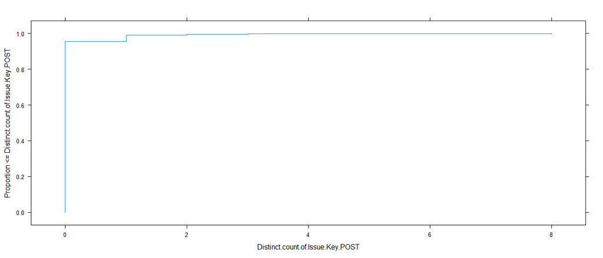

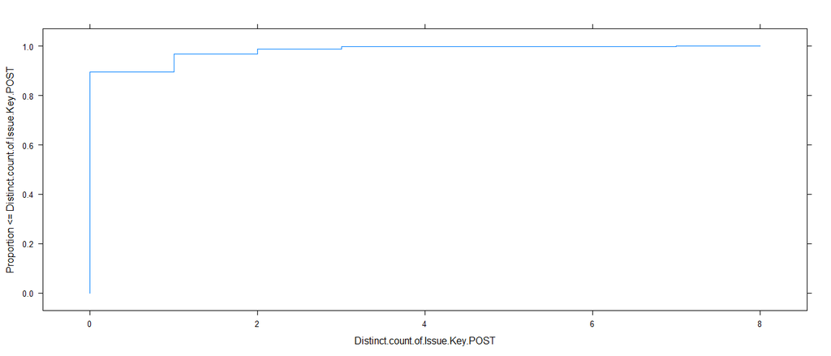

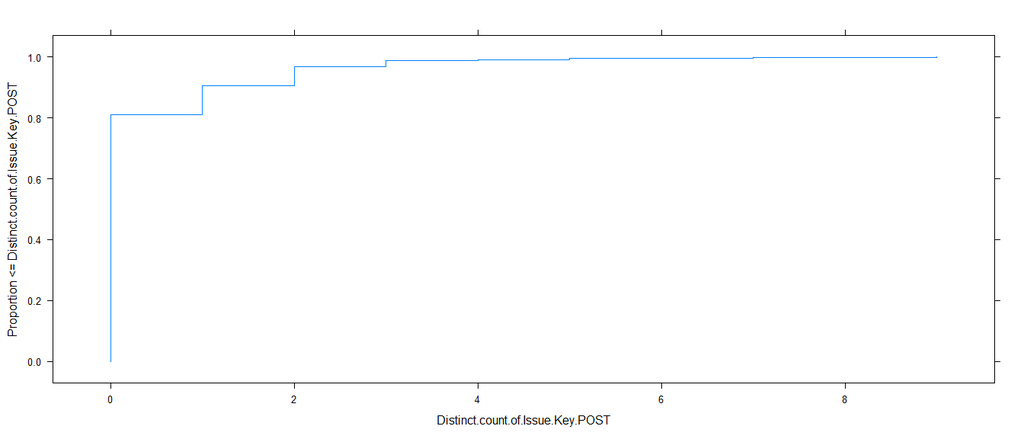

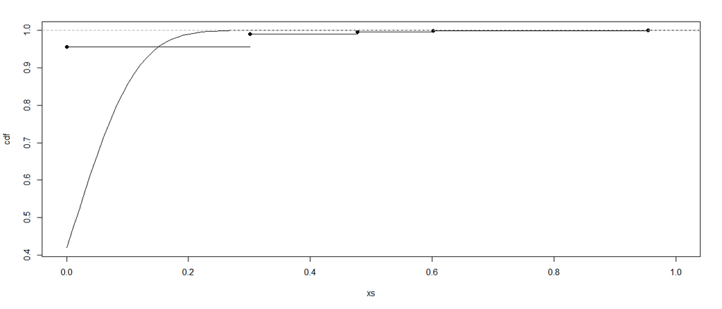

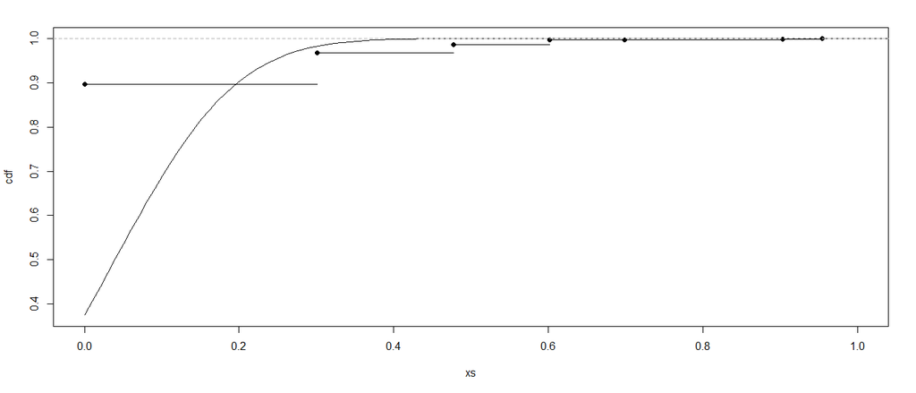

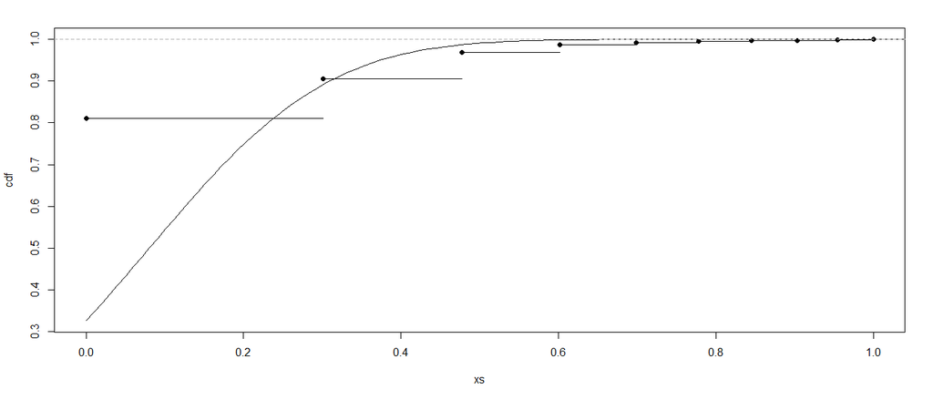

```r
modelSelectionAndNormalityAdjustment(all_list_omitted)
```

## Model 0 - BASE Only

Before looking into models that include catch blocks or throws blocks data we would consider also models that only have base metrics. We aim to understand the difference between BASE only metrics and BASE + EH Metrics ### Drop variables

```r
all_list_omitted_m0 = vector("list", 0)
for (i in 1:length(projects)) {
  print(paste("Project:", projects[i]))
  temp_data = all_list_omitted[[i]]$data

  temp_data = temp_data[,!(names(temp_data) %in% catch_names)]
  temp_data = temp_data[,!(names(temp_data) %in% try_names)]
  temp_data = temp_data[,!(names(temp_data) %in% throws_names)]

  print(nrow(temp_data))
  print(names(temp_data))

  all_list_omitted_m0 <- c(all_list_omitted_m0, list(temp_data))
}
```

```
[1] "Project: Jmeter"
[1] 828
 [1] "Distinct.count.of.Issue.Key.POST"   "Distinct.count.of.Issue.Key.PRE"
 [3] "Churn.PRE"                          "Distinct.count.of.Author.Email.PRE"
 [5] "Distinct.count.of.Commit.Hash.PRE"  "Kind"
 [7] "File"                               "AvgCyclomatic"
 [9] "AvgCyclomaticModified"              "AvgCyclomaticStrict"
[11] "AvgEssential"                       "AvgLine"
[13] "AvgLineBlank"                       "AvgLineCode"
[15] "AvgLineComment"                     "CountDeclClass"
[17] "CountDeclClassMethod"               "CountDeclClassVariable"
[19] "CountDeclExecutableUnit"            "CountDeclFunction"
[21] "CountDeclInstanceMethod"            "CountDeclInstanceVariable"
[23] "CountDeclMethod"                    "CountDeclMethodDefault"
[25] "CountDeclMethodPrivate"             "CountDeclMethodProtected"
```

[output cut: 66 more lines]

```r
dropToPredict = c("File.Path",  "Project", "Language", "Table.Name","Name","Kind", "X..Bugs.Post", "File", "Distinct.count.of.Issue.Key.POST")
```

### Correlation analysis (MC4), Redundancy Analysis (MC5), Budget based correlation analysis (MC6)

```
[1] "Project: Jmeter"
[1] "NumberOfMetricsInitial: 44"
[1] "NumberOfMetricsKept: 14"
[1] "Distinct.count.of.Issue.Key.PRE + Churn.PRE + Distinct.count.of.Commit.Hash.PRE + AvgEssential + AvgLineBlank + AvgLineComment + CountDeclClass + CountDeclClassMethod + CountDeclClassVariable + CountDeclInstanceVariable + CountDeclMethodDefault + CountDeclMethodPrivate + CountDeclMethodProtecte…
[1] "Project: Cassandra"
```

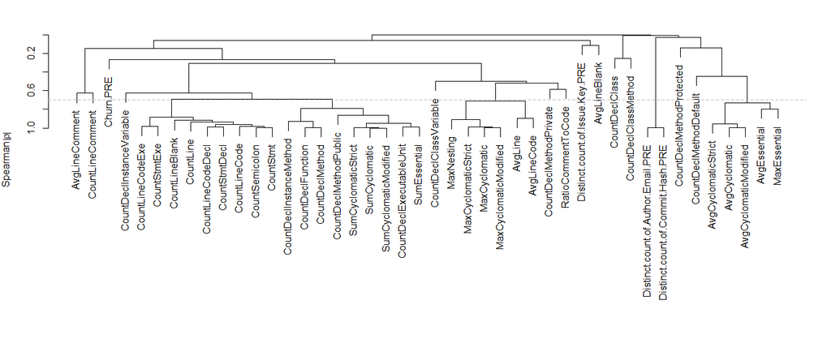

```
[1] "NumberOfMetricsInitial: 44"
[1] "NumberOfMetricsKept: 17"
[1] "Distinct.count.of.Issue.Key.PRE + Distinct.count.of.Commit.Hash.PRE + AvgCyclomaticModified + AvgEssential + AvgLineBlank + AvgLineComment + CountDeclClass + CountDeclClassMethod + CountDeclClassVariable + CountDeclInstanceMethod + CountDeclInstanceVariable + CountDeclMethodDefault + CountDeclM…
[1] "Project: Calcite"
```

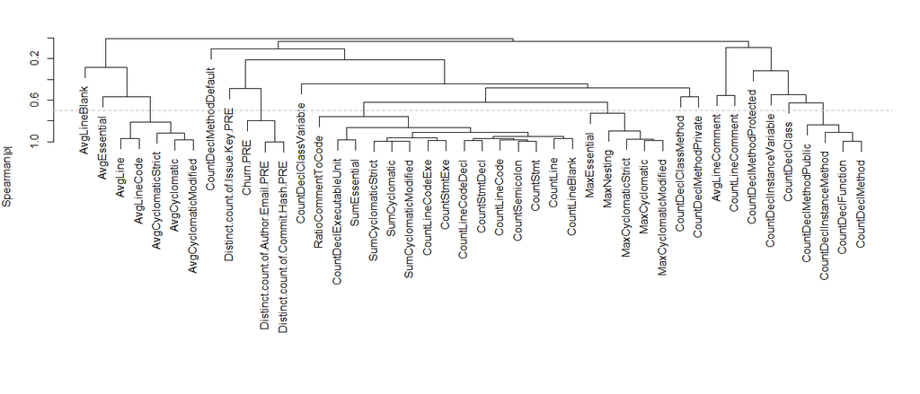

```
[1] "NumberOfMetricsInitial: 44"
[1] "NumberOfMetricsKept: 15"
[1] "Distinct.count.of.Issue.Key.PRE + Churn.PRE + Distinct.count.of.Author.Email.PRE + AvgEssential + AvgLineBlank + AvgLineComment + CountDeclClass + CountDeclClassMethod + CountDeclClassVariable + CountDeclInstanceMethod + CountDeclInstanceVariable + CountDeclMethodDefault + CountDeclMethodPrivat…
[1] "Project: Jmeter"
[1] "Redudant variables: "
[1] "Distinct.count.of.Issue.Key.POST + Distinct.count.of.Issue.Key.PRE + Churn.PRE + Distinct.count.of.Commit.Hash.PRE + Kind + File + AvgEssential + AvgLineBlank + AvgLineComment + CountDeclClass + CountDeclClassMethod + CountDeclClassVariable + CountDeclInstanceVariable + CountDeclMethodDefault +…
[1] "Project: Cassandra"
[1] "Redudant variables: "
[1] "Distinct.count.of.Issue.Key.POST + Distinct.count.of.Issue.Key.PRE + Distinct.count.of.Commit.Hash.PRE + Kind + File + AvgCyclomaticModified + AvgEssential + AvgLineBlank + AvgLineComment + CountDeclClass + CountDeclClassMethod + CountDeclClassVariable + CountDeclInstanceMethod + CountDeclInsta…
[1] "Project: Calcite"
[1] "Redudant variables: "
[1] "Distinct.count.of.Issue.Key.POST + Distinct.count.of.Issue.Key.PRE + Churn.PRE + Distinct.count.of.Author.Email.PRE + Kind + File + AvgEssential + AvgLineBlank + AvgLineComment + CountDeclClass + CountDeclClassMethod + CountDeclClassVariable + CountDeclInstanceMethod + CountDeclInstanceVariable…
[1] "Project: Jmeter"
[1] "NumberOfMetricsInitial: 14 Budget: 55 Over Budget: FALSE NumberOfMetricsKept: 14 CorrelationCutoff: 0.7"
[1] "Project: Cassandra"
[1] "NumberOfMetricsInitial: 17 Budget: 86 Over Budget: FALSE NumberOfMetricsKept: 17 CorrelationCutoff: 0.7"
[1] "Project: Calcite"
[1] "NumberOfMetricsInitial: 15 Budget: 97 Over Budget: FALSE NumberOfMetricsKept: 15 CorrelationCutoff: 0.7"
```

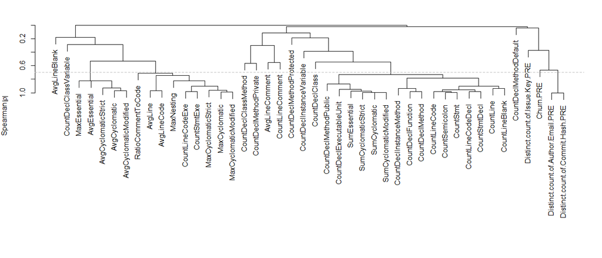

```r
all_list_model_m0 = dataApplyReduction(all_list_omitted_m0)
```

### Setup formulas

```r
form_list_bin_m0 = dataSetupFormulasBinary(all_list_model_m0)
```

```
[1] "Project: Jmeter"
[1] "Distinct.count.of.Issue.Key.PRE + Churn.PRE + Distinct.count.of.Commit.Hash.PRE + AvgEssential + AvgLineBlank + AvgLineComment + CountDeclClass + CountDeclClassMethod + CountDeclClassVariable + CountDeclInstanceVariable + CountDeclMethodDefault + CountDeclMethodPrivate + CountDeclMethodProtecte…
[1] "Project: Cassandra"
[1] "Distinct.count.of.Issue.Key.PRE + Distinct.count.of.Commit.Hash.PRE + AvgCyclomaticModified + AvgEssential + AvgLineBlank + AvgLineComment + CountDeclClass + CountDeclClassMethod + CountDeclClassVariable + CountDeclInstanceMethod + CountDeclInstanceVariable + CountDeclMethodDefault + CountDeclM…
[1] "Project: Calcite"
[1] "Distinct.count.of.Issue.Key.PRE + Churn.PRE + Distinct.count.of.Author.Email.PRE + AvgEssential + AvgLineBlank + AvgLineComment + CountDeclClass + CountDeclClassMethod + CountDeclClassVariable + CountDeclInstanceMethod + CountDeclInstanceVariable + CountDeclMethodDefault + CountDeclMethodPrivat…
```

### Fit regression model (MC7)

```r
models_1_BASE = modelFitLogistic(all_list_model_m0,form_list_bin_m0,"ALL.BASE")
```

```
[1] "Project: Jmeter"
Logistic Regression Model

 lrm(formula = as.formula(form_bin), data = temp_data_log, x = T,
     y = T)

                        Model Likelihood    Discrimination    Rank Discrim.
                              Ratio Test           Indexes          Indexes
 Obs           828    LR chi2     151.29    R2       0.546    C       0.950
  FALSE        791    d.f.            14    g        1.905    Dxy     0.901
  TRUE          37    Pr(> chi2) <0.0001    gr       6.717    gamma   0.902
 max |deriv| 7e-06                          gp       0.075    tau-a   0.077
                                            Brier    0.025

                                   Coef    S.E.   Wald Z Pr(>|Z|)
 Intercept                         -5.5262 3.0355 -1.82  0.0687
 Distinct.count.of.Issue.Key.PRE    2.9349 2.1029  1.40  0.1628
 Churn.PRE                          3.3785 0.4752  7.11  <0.0001
 Distinct.count.of.Commit.Hash.PRE -1.7222 3.7098 -0.46  0.6425
 AvgEssential                       3.7919 5.0140  0.76  0.4495
 AvgLineBlank                      -6.5277 2.5457 -2.56  0.0103
 AvgLineComment                     0.4738 1.2994  0.36  0.7154
 CountDeclClass                     1.5202 2.3811  0.64  0.5232
 CountDeclClassMethod               0.6690 0.9343  0.72  0.4739
 CountDeclClassVariable            -0.2929 0.8012 -0.37  0.7147
 CountDeclInstanceVariable         -0.5374 0.8186 -0.66  0.5115
 CountDeclMethodDefault             0.9239 1.5761  0.59  0.5578
 CountDeclMethodPrivate             0.9575 0.9243  1.04  0.3002
 CountDeclMethodProtected           2.4600 0.7900  3.11  0.0018
 CountLineComment                  -0.6685 1.6063 -0.42  0.6773

[1] "Project: Cassandra"
Logistic Regression Model

 lrm(formula = as.formula(form_bin), data = temp_data_log, x = T,
     y = T)

                        Model Likelihood    Discrimination    Rank Discrim.
                              Ratio Test           Indexes          Indexes
 Obs          1293    LR chi2     176.99    R2       0.263    C       0.812
```

[output cut: 41 more lines]

```
 Distinct.count.of.Issue.Key.PRE     2.0832 0.6109  3.41  0.0006
 Churn.PRE                           0.2929 0.1963  1.49  0.1356
 Distinct.count.of.Author.Email.PRE -0.4584 0.7443 -0.62  0.5380
 AvgEssential                        0.7070 0.8089  0.87  0.3821
 AvgLineBlank                        3.0685 0.6474  4.74  <0.0001
 AvgLineComment                      0.7861 0.3880  2.03  0.0427
 CountDeclClass                     -0.0113 0.5461 -0.02  0.9834
 CountDeclClassMethod               -0.2355 0.3092 -0.76  0.4462
 CountDeclClassVariable              2.1916 0.3491  6.28  <0.0001
 CountDeclInstanceMethod             1.3548 0.3133  4.32  <0.0001
 CountDeclInstanceVariable          -0.7200 0.2491 -2.89  0.0039
 CountDeclMethodDefault             -0.3634 0.2995 -1.21  0.2250
 CountDeclMethodPrivate              0.3437 0.3476  0.99  0.3227
 CountDeclMethodProtected           -0.2860 0.4181 -0.68  0.4938
 CountLineComment                    0.9796 0.4937  1.98  0.0472
```

## Model 1 - BASE + N Throws + N Catch

```r
all_list_omitted_m1 = vector("list", 0)
for (i in 1:length(projects)) {
  print(paste("Project:", projects[i]))
  temp_data = all_list_omitted[[i]]$data

  keepForID = c("Project", "File.Path")
  keepForCatch = c("X..Catch",keepForID)
  keepForTry = c(keepForID)
  keepForThrows = c("X..Throws", keepForID)

  catch_names_drop = catch_names[!(catch_names %in% keepForCatch)]
  try_names_drop = try_names[!(try_names %in% keepForTry)]
  throws_names_drop = throws_names[!(throws_names %in% keepForThrows)]

  temp_data = temp_data[,!(names(temp_data) %in% catch_names_drop)]
  temp_data = temp_data[,!(names(temp_data) %in% try_names_drop)]
  temp_data = temp_data[,!(names(temp_data) %in% throws_names_drop)]

  print(names(temp_data))

  all_list_omitted_m1 <- c(all_list_omitted_m1, list(temp_data))
}
```

```
[1] "Project: Jmeter"
 [1] "File.Path"                          "Project"
 [3] "Distinct.count.of.Issue.Key.POST"   "Distinct.count.of.Issue.Key.PRE"
 [5] "Churn.PRE"                          "Distinct.count.of.Author.Email.PRE"
 [7] "Distinct.count.of.Commit.Hash.PRE"  "Kind"
 [9] "File"                               "AvgCyclomatic"
[11] "AvgCyclomaticModified"              "AvgCyclomaticStrict"
[13] "AvgEssential"                       "AvgLine"
[15] "AvgLineBlank"                       "AvgLineCode"
[17] "AvgLineComment"                     "CountDeclClass"
[19] "CountDeclClassMethod"               "CountDeclClassVariable"
[21] "CountDeclExecutableUnit"            "CountDeclFunction"
[23] "CountDeclInstanceMethod"            "CountDeclInstanceVariable"
[25] "CountDeclMethod"                    "CountDeclMethodDefault"
[27] "CountDeclMethodPrivate"             "CountDeclMethodProtected"
```

[output cut: 69 more lines]

```r
dropToPredict = c("File.Path",  "Project", "Language", "Table.Name","Name","Kind", "X..Bugs.Post", "File", "Distinct.count.of.Issue.Key.POST")
```

### Correlation analysis (MC4), Redundancy Analysis (MC5), Budget based correlation analysis (MC6)

```
[1] "Project: Jmeter"
[1] "NumberOfMetricsInitial: 46"
[1] "NumberOfMetricsKept: 16"
[1] "Distinct.count.of.Issue.Key.PRE + Churn.PRE + Distinct.count.of.Commit.Hash.PRE + AvgEssential + AvgLineBlank + AvgLineComment + CountDeclClass + CountDeclClassMethod + CountDeclClassVariable + CountDeclInstanceVariable + CountDeclMethodDefault + CountDeclMethodPrivate + CountDeclMethodProtecte…
[1] "Project: Cassandra"
```

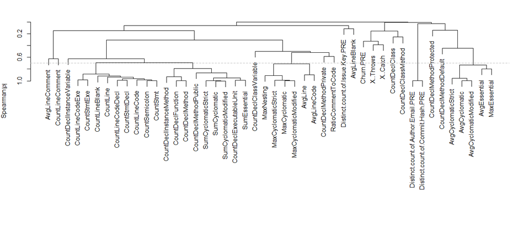

```
[1] "NumberOfMetricsInitial: 46"
[1] "NumberOfMetricsKept: 19"
[1] "Distinct.count.of.Issue.Key.PRE + Distinct.count.of.Commit.Hash.PRE + AvgCyclomaticModified + AvgEssential + AvgLineBlank + AvgLineComment + CountDeclClass + CountDeclClassMethod + CountDeclClassVariable + CountDeclInstanceMethod + CountDeclInstanceVariable + CountDeclMethodDefault + CountDeclM…
[1] "Project: Calcite"
```

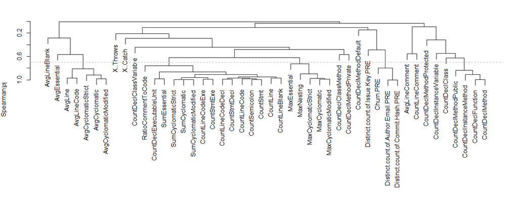

```
[1] "NumberOfMetricsInitial: 46"
[1] "NumberOfMetricsKept: 16"
[1] "Distinct.count.of.Issue.Key.PRE + Churn.PRE + Distinct.count.of.Author.Email.PRE + AvgEssential + AvgLineBlank + AvgLineComment + CountDeclClass + CountDeclClassMethod + CountDeclClassVariable + CountDeclInstanceMethod + CountDeclInstanceVariable + CountDeclMethodDefault + CountDeclMethodPrivat…
[1] "Project: Jmeter"
[1] "Redudant variables: "
[1] "File.Path + Project + Distinct.count.of.Issue.Key.POST + Distinct.count.of.Issue.Key.PRE + Churn.PRE + Distinct.count.of.Commit.Hash.PRE + Kind + File + AvgEssential + AvgLineBlank + AvgLineComment + CountDeclClass + CountDeclClassMethod + CountDeclClassVariable + CountDeclInstanceVariable + Co…
[1] "Project: Cassandra"
[1] "Redudant variables: "
[1] "File.Path + Project + Distinct.count.of.Issue.Key.POST + Distinct.count.of.Issue.Key.PRE + Distinct.count.of.Commit.Hash.PRE + Kind + File + AvgCyclomaticModified + AvgEssential + AvgLineBlank + AvgLineComment + CountDeclClass + CountDeclClassMethod + CountDeclClassVariable + CountDeclInstanceM…
[1] "Project: Calcite"
[1] "Redudant variables: "
[1] "File.Path + Project + Distinct.count.of.Issue.Key.POST + Distinct.count.of.Issue.Key.PRE + Churn.PRE + Distinct.count.of.Author.Email.PRE + Kind + File + AvgEssential + AvgLineBlank + AvgLineComment + CountDeclClass + CountDeclClassMethod + CountDeclClassVariable + CountDeclInstanceMethod + Cou…
[1] "Project: Jmeter"
[1] "NumberOfMetricsInitial: 16 Budget: 55 Over Budget: FALSE NumberOfMetricsKept: 16 CorrelationCutoff: 0.7"
[1] "Project: Cassandra"
[1] "NumberOfMetricsInitial: 19 Budget: 86 Over Budget: FALSE NumberOfMetricsKept: 19 CorrelationCutoff: 0.7"
[1] "Project: Calcite"
[1] "NumberOfMetricsInitial: 16 Budget: 97 Over Budget: FALSE NumberOfMetricsKept: 16 CorrelationCutoff: 0.7"
```

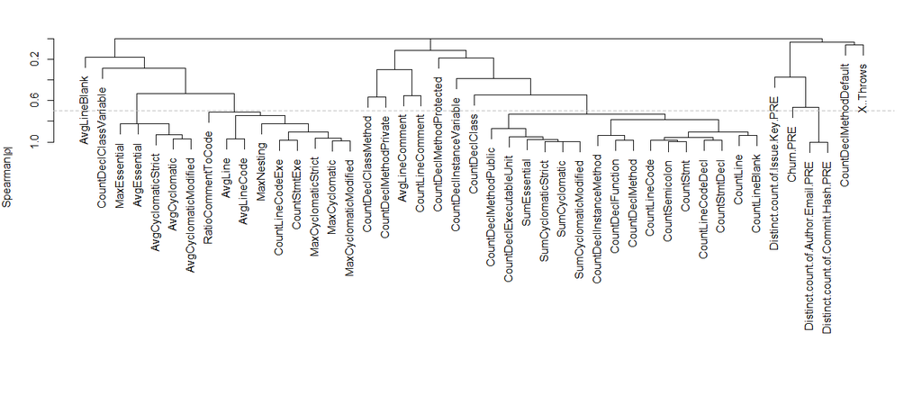

```r
all_list_model_m1 = dataApplyReduction(all_list_omitted_m1)
```

### Setup formulas

```r
form_list_bin_m1 = dataSetupFormulasBinary(all_list_model_m1)
```

```
[1] "Project: Jmeter"
[1] "Distinct.count.of.Issue.Key.PRE + Churn.PRE + Distinct.count.of.Commit.Hash.PRE + AvgEssential + AvgLineBlank + AvgLineComment + CountDeclClass + CountDeclClassMethod + CountDeclClassVariable + CountDeclInstanceVariable + CountDeclMethodDefault + CountDeclMethodPrivate + CountDeclMethodProtecte…
[1] "Project: Cassandra"
[1] "Distinct.count.of.Issue.Key.PRE + Distinct.count.of.Commit.Hash.PRE + AvgCyclomaticModified + AvgEssential + AvgLineBlank + AvgLineComment + CountDeclClass + CountDeclClassMethod + CountDeclClassVariable + CountDeclInstanceMethod + CountDeclInstanceVariable + CountDeclMethodDefault + CountDeclM…
[1] "Project: Calcite"
[1] "Distinct.count.of.Issue.Key.PRE + Churn.PRE + Distinct.count.of.Author.Email.PRE + AvgEssential + AvgLineBlank + AvgLineComment + CountDeclClass + CountDeclClassMethod + CountDeclClassVariable + CountDeclInstanceMethod + CountDeclInstanceVariable + CountDeclMethodDefault + CountDeclMethodPrivat…
```

### Fit regression model (MC7)

```r
models_1_BSEH = modelFitLogistic(all_list_model_m1,form_list_bin_m1,"ALL.BSEH")
```

[output not shown]

## Model Analysis for ALL

In this section, we present the selected statistics for our analysis. As explained in our approach, they are the steps: MC7, MA1, MA2, MA3 and MA4.

Here we extract the selected statistics and we add the data (columns) to an object that will be exported to CSV in the section Output.

### Fit regression model (MC7): summary stats

```r
model_things_1_BASE = vector("list", 0)
model_things_1_BSEH = vector("list", 0)
model_things_1_BASE = modelStats(models_1_BASE)
model_things_1_BSEH = modelStats(models_1_BSEH)
```

### Model stability assessment (MA1)

```r
model_things_1_BASE = modelValidate(models_1_BASE, model_things_1_BASE)
```

```
Divergence or singularity in 1 samples
```

```r
model_things_1_BSEH = modelValidate(models_1_BSEH, model_things_1_BSEH)
```

### Model significant variables

```r
model_things_1_BASE = modelSignificance(models_1_BASE, model_things_1_BASE)
```

```
[1] "project:  Jmeter model:  ALL.BASE"
                Wald Statistics          Response: Distinct.count.of.Issue.Key.POST > 0

 Factor                            Chi-Square d.f. P
 Distinct.count.of.Issue.Key.PRE    1.95       1   0.1628
 Churn.PRE                         50.54       1   <.0001
 Distinct.count.of.Commit.Hash.PRE  0.22       1   0.6425
 AvgEssential                       0.57       1   0.4495
 AvgLineBlank                       6.58       1   0.0103
 AvgLineComment                     0.13       1   0.7154
 CountDeclClass                     0.41       1   0.5232
 CountDeclClassMethod               0.51       1   0.4739
 CountDeclClassVariable             0.13       1   0.7147
 CountDeclInstanceVariable          0.43       1   0.5115
 CountDeclMethodDefault             0.34       1   0.5578
 CountDeclMethodPrivate             1.07       1   0.3002
 CountDeclMethodProtected           9.70       1   0.0018
 CountLineComment                   0.17       1   0.6773
 TOTAL                             80.70      14   <.0001
[1] "project:  Cassandra model:  ALL.BASE"
                Wald Statistics          Response: Distinct.count.of.Issue.Key.POST > 0

 Factor                            Chi-Square d.f. P
 Distinct.count.of.Issue.Key.PRE     3.38      1   0.0661
 Distinct.count.of.Commit.Hash.PRE   4.30      1   0.0381
 AvgCyclomaticModified               2.77      1   0.0962
 AvgEssential                        1.26      1   0.2613
 AvgLineBlank                        5.18      1   0.0228
 AvgLineComment                      0.04      1   0.8502
 CountDeclClass                      1.24      1   0.2659
 CountDeclClassMethod                0.25      1   0.6199
 CountDeclClassVariable              9.33      1   0.0023
 CountDeclInstanceMethod             1.20      1   0.2732
 CountDeclInstanceVariable           1.17      1   0.2799
 CountDeclMethodDefault              1.49      1   0.2219
 CountDeclMethodPrivate              0.95      1   0.3294
 CountDeclMethodProtected            2.95      1   0.0858
 CountLineComment                    3.71      1   0.0540
 MaxEssential                        1.31      1   0.2517
 RatioCommentToCode                  4.41      1   0.0356
 TOTAL                             134.92     17   <.0001
[1] "project:  Calcite model:  ALL.BASE"
                Wald Statistics          Response: Distinct.count.of.Issue.Key.POST > 0

 Factor                             Chi-Square d.f. P
 Distinct.count.of.Issue.Key.PRE     11.63      1   0.0006
 Churn.PRE                            2.23      1   0.1356
 Distinct.count.of.Author.Email.PRE   0.38      1   0.5380
 AvgEssential                         0.76      1   0.3821
 AvgLineBlank                        22.46      1   <.0001
 AvgLineComment                       4.11      1   0.0427
 CountDeclClass                       0.00      1   0.9834
 CountDeclClassMethod                 0.58      1   0.4462
 CountDeclClassVariable              39.41      1   <.0001
 CountDeclInstanceMethod             18.70      1   <.0001
 CountDeclInstanceVariable            8.35      1   0.0039
 CountDeclMethodDefault               1.47      1   0.2250
 CountDeclMethodPrivate               0.98      1   0.3227
 CountDeclMethodProtected             0.47      1   0.4938
 CountLineComment                     3.94      1   0.0472
 TOTAL                              242.22     15   <.0001
```

```r
model_things_1_BSEH = modelSignificance(models_1_BSEH, model_things_1_BSEH)
```

```
[1] "project:  Calcite model:  ALL.BSEH"
                Wald Statistics          Response: Distinct.count.of.Issue.Key.POST > 0

 Factor                             Chi-Square d.f. P
 Distinct.count.of.Issue.Key.PRE     11.40      1   0.0007
 Churn.PRE                            1.49      1   0.2220
 Distinct.count.of.Author.Email.PRE   0.19      1   0.6591
 AvgEssential                         0.66      1   0.4166
 AvgLineBlank                        22.09      1   <.0001
 AvgLineComment                       4.90      1   0.0269
 CountDeclClass                       0.01      1   0.9377
 CountDeclClassMethod                 0.48      1   0.4900
 CountDeclClassVariable              40.23      1   <.0001
 CountDeclInstanceMethod             19.36      1   <.0001
 CountDeclInstanceVariable            8.03      1   0.0046
 CountDeclMethodDefault               1.05      1   0.3063
 CountDeclMethodPrivate               1.50      1   0.2208
 CountDeclMethodProtected             0.59      1   0.4440
 CountLineComment                     3.51      1   0.0612
 X..Throws                            3.30      1   0.0692
 TOTAL                              242.92     16   <.0001
```

### Model simplification (MA2), Predictors’ explanatory power estimation (MA3), Predictors’ effect in the outcome measurement (MA4)

```r
model_things_1_BASE = modelSimplification(models_1_BASE, model_things_1_BASE)
```

```
[1] "project:  Jmeter model:  ALL.BASE Refit"
Logistic Regression Model

 lrm(formula = as.formula(final_form), data = temp_data, x = T,
     y = T)

                        Model Likelihood    Discrimination    Rank Discrim.
                              Ratio Test           Indexes          Indexes
 Obs           828    LR chi2     143.69    R2       0.521    C       0.945
  FALSE        791    d.f.             3    g        1.538    Dxy     0.891
  TRUE          37    Pr(> chi2) <0.0001    gr       4.654    gamma   0.910
 max |deriv| 5e-08                          gp       0.073    tau-a   0.076
                                            Brier    0.026

                          Coef    S.E.   Wald Z Pr(>|Z|)
 Intercept                -5.2293 0.4309 -12.13 <0.0001
 Churn.PRE                 3.5560 0.4052   8.78 <0.0001
 AvgLineBlank             -5.0293 2.1407  -2.35 0.0188
 CountDeclMethodProtected  2.0703 0.6234   3.32 0.0009

[1] "project:  Jmeter model:  ALL.BASE Refit - summary"
[1] "project:  Jmeter model:  ALL.BASE Refit - validate"
[1] "project:  Jmeter model:  ALL.BASE Refit - anova"
                Wald Statistics          Response: Distinct.count.of.Issue.Key.POST > 0

 Factor                   Chi-Square d.f. P
 Churn.PRE                77.03      1    <.0001
 AvgLineBlank              5.52      1    0.0188
 CountDeclMethodProtected 11.03      1    0.0009
 TOTAL                    84.30      3    <.0001
[1] "Churn.PRE"
[1] "AvgLineBlank"
[1] "CountDeclMethodProtected"
```

| Churn.PRE | AvgLineBlank | CountDeclMethodProtected |
| --- | --- | --- |
| 2.727053 | 0.2173913 | 0.5422705 |

```
[1] "Fixed at Mean: 0.0377754505727432"
[1] "Churn.PRE  Coef at Mean + 10%: 0.041945555638496"
[1] "AvgLineBlank  Coef at Mean + 10%: 0.0363950742651731"
[1] "CountDeclMethodProtected  Coef at Mean + 10%: 0.0389211520034613"
[1] "project:  Cassandra model:  ALL.BASE Refit"
Logistic Regression Model

 lrm(formula = as.formula(final_form), data = temp_data, x = T,
     y = T)

                        Model Likelihood    Discrimination    Rank Discrim.
                              Ratio Test           Indexes          Indexes
 Obs          1293    LR chi2     158.23    R2       0.237    C       0.797
  FALSE       1159    d.f.             4    g        1.383    Dxy     0.593
  TRUE         134    Pr(> chi2) <0.0001    gr       3.988    gamma   0.593
 max |deriv| 4e-11                          gp       0.111    tau-a   0.110
                                            Brier    0.078

                                   Coef    S.E.   Wald Z Pr(>|Z|)
 Intercept                         -4.7546 0.5160 -9.21  <0.0001
 Distinct.count.of.Commit.Hash.PRE  2.5050 0.7561  3.31  0.0009
 CountDeclClassVariable             0.9620 0.3100  3.10  0.0019
 CountLineComment                   1.7088 0.3286  5.20  <0.0001
 RatioCommentToCode                -4.0414 1.1475 -3.52  0.0004

[1] "project:  Cassandra model:  ALL.BASE Refit - summary"
[1] "project:  Cassandra model:  ALL.BASE Refit - validate"
[1] "project:  Cassandra model:  ALL.BASE Refit - anova"
                Wald Statistics          Response: Distinct.count.of.Issue.Key.POST > 0

 Factor                            Chi-Square d.f. P
 Distinct.count.of.Commit.Hash.PRE  10.98     1    0.0009
 CountDeclClassVariable              9.63     1    0.0019
 CountLineComment                   27.04     1    <.0001
 RatioCommentToCode                 12.40     1    0.0004
 TOTAL                             124.24     4    <.0001
[1] "Distinct.count.of.Commit.Hash.PRE"
[1] "CountDeclClassVariable"
[1] "CountLineComment"
[1] "RatioCommentToCode"
```

| Distinct.count.of.Commit.Hash.PRE | CountDeclClassVariable | CountLineComment | RatioCommentToCode |
| --- | --- | --- | --- |
| 0.1500387 | 1.576953 | 43.22042 | 0.8585228 |

```
[1] "Fixed at Mean: 0.0770787415774354"
[1] "Distinct.count.of.Commit.Hash.PRE  Coef at Mean + 10%: 0.0780878841067753"
[1] "CountDeclClassVariable  Coef at Mean + 10%: 0.0788627233960897"
[1] "CountLineComment  Coef at Mean + 10%: 0.0821482722124231"
[1] "RatioCommentToCode  Coef at Mean + 10%: 0.0716260143964796"
[1] "project:  Calcite model:  ALL.BASE Refit"
Logistic Regression Model

 lrm(formula = as.formula(final_form), data = temp_data, x = T,
     y = T)

                        Model Likelihood    Discrimination    Rank Discrim.
                              Ratio Test           Indexes          Indexes
 Obs          1460    LR chi2     356.43    R2       0.349    C       0.837
  FALSE       1184    d.f.             6    g        1.457    Dxy     0.674
  TRUE         276    Pr(> chi2) <0.0001    gr       4.292    gamma   0.676
 max |deriv| 2e-10                          gp       0.196    tau-a   0.207
                                            Brier    0.113

                                 Coef    S.E.   Wald Z Pr(>|Z|)
 Intercept                       -3.6446 0.2102 -17.34 <0.0001
 Distinct.count.of.Issue.Key.PRE  2.5696 0.5199   4.94 <0.0001
 AvgLineBlank                     3.1879 0.6013   5.30 <0.0001
 AvgLineComment                   1.4071 0.2811   5.01 <0.0001
 CountDeclClassVariable           2.4615 0.3180   7.74 <0.0001
 CountDeclInstanceMethod          1.6546 0.2308   7.17 <0.0001
 CountDeclInstanceVariable       -0.6117 0.2279  -2.68 0.0073

[1] "project:  Calcite model:  ALL.BASE Refit - summary"
[1] "project:  Calcite model:  ALL.BASE Refit - validate"
[1] "project:  Calcite model:  ALL.BASE Refit - anova"
                Wald Statistics          Response: Distinct.count.of.Issue.Key.POST > 0

 Factor                          Chi-Square d.f. P
 Distinct.count.of.Issue.Key.PRE  24.43     1    <.0001
 AvgLineBlank                     28.11     1    <.0001
 AvgLineComment                   25.06     1    <.0001
 CountDeclClassVariable           59.92     1    <.0001
 CountDeclInstanceMethod          51.40     1    <.0001
 CountDeclInstanceVariable         7.20     1    0.0073
 TOTAL                           239.16     6    <.0001
[1] "Distinct.count.of.Issue.Key.PRE"
[1] "AvgLineBlank"
[1] "AvgLineComment"
[1] "CountDeclClassVariable"
[1] "CountDeclInstanceMethod"
[1] "CountDeclInstanceVariable"
```

| Distinct.count.of.Issue.Key.PRE | AvgLineBlank | AvgLineComment | CountDeclClassVariable | CountDeclInstanceMethod | CountDeclInstanceVariable |
| --- | --- | --- | --- | --- | --- |
| 0.1958904 | 0.1342466 | 1.034932 | 0.8547945 | 8.587671 | 2.817808 |

```
[1] "Fixed at Mean: 0.287497849556867"
[1] "Distinct.count.of.Issue.Key.PRE  Coef at Mean + 10%: 0.291226309899571"
[1] "AvgLineBlank  Coef at Mean + 10%: 0.29084631984034"
[1] "AvgLineComment  Coef at Mean + 10%: 0.293747612148684"
[1] "CountDeclClassVariable  Coef at Mean + 10%: 0.297463990126818"
[1] "CountDeclInstanceMethod  Coef at Mean + 10%: 0.300288100997195"
[1] "CountDeclInstanceVariable  Coef at Mean + 10%: 0.283638450902878"
```

```r
model_things_1_BSEH = modelSimplification(models_1_BSEH, model_things_1_BSEH)
```

```
[1] "project:  Jmeter model:  ALL.BSEH Refit"
[1] NA
[1] "project:  Cassandra model:  ALL.BSEH Refit"
[1] NA
[1] "project:  Calcite model:  ALL.BSEH Refit"
Logistic Regression Model

 lrm(formula = as.formula(final_form), data = temp_data, x = T,
     y = T)

                        Model Likelihood    Discrimination    Rank Discrim.
                              Ratio Test           Indexes          Indexes
 Obs          1460    LR chi2     356.43    R2       0.349    C       0.837
  FALSE       1184    d.f.             6    g        1.457    Dxy     0.674
  TRUE         276    Pr(> chi2) <0.0001    gr       4.292    gamma   0.676
 max |deriv| 2e-10                          gp       0.196    tau-a   0.207
                                            Brier    0.113

                                 Coef    S.E.   Wald Z Pr(>|Z|)
 Intercept                       -3.6446 0.2102 -17.34 <0.0001
 Distinct.count.of.Issue.Key.PRE  2.5696 0.5199   4.94 <0.0001
 AvgLineBlank                     3.1879 0.6013   5.30 <0.0001
 AvgLineComment                   1.4071 0.2811   5.01 <0.0001
 CountDeclClassVariable           2.4615 0.3180   7.74 <0.0001
 CountDeclInstanceMethod          1.6546 0.2308   7.17 <0.0001
 CountDeclInstanceVariable       -0.6117 0.2279  -2.68 0.0073

[1] "project:  Calcite model:  ALL.BSEH Refit - summary"
[1] "project:  Calcite model:  ALL.BSEH Refit - validate"
[1] "project:  Calcite model:  ALL.BSEH Refit - anova"
                Wald Statistics          Response: Distinct.count.of.Issue.Key.POST > 0

 Factor                          Chi-Square d.f. P
 Distinct.count.of.Issue.Key.PRE  24.43     1    <.0001
 AvgLineBlank                     28.11     1    <.0001
 AvgLineComment                   25.06     1    <.0001
 CountDeclClassVariable           59.92     1    <.0001
 CountDeclInstanceMethod          51.40     1    <.0001
 CountDeclInstanceVariable         7.20     1    0.0073
 TOTAL                           239.16     6    <.0001
[1] "Distinct.count.of.Issue.Key.PRE"
[1] "AvgLineBlank"
[1] "AvgLineComment"
[1] "CountDeclClassVariable"
[1] "CountDeclInstanceMethod"
[1] "CountDeclInstanceVariable"
```

| Distinct.count.of.Issue.Key.PRE | AvgLineBlank | AvgLineComment | CountDeclClassVariable | CountDeclInstanceMethod | CountDeclInstanceVariable |
| --- | --- | --- | --- | --- | --- |
| 0.1958904 | 0.1342466 | 1.034932 | 0.8547945 | 8.587671 | 2.817808 |

```
[1] "Fixed at Mean: 0.287497849556867"
[1] "Distinct.count.of.Issue.Key.PRE  Coef at Mean + 10%: 0.291226309899571"
[1] "AvgLineBlank  Coef at Mean + 10%: 0.29084631984034"
[1] "AvgLineComment  Coef at Mean + 10%: 0.293747612148684"
[1] "CountDeclClassVariable  Coef at Mean + 10%: 0.297463990126818"
[1] "CountDeclInstanceMethod  Coef at Mean + 10%: 0.300288100997195"
[1] "CountDeclInstanceVariable  Coef at Mean + 10%: 0.283638450902878"
```

## Output 1

Here we output the selected statistics from the R functions results and we output in the CSV files in the folder “output”.

```r
write.table(data.frame(model_things_1_BASE[[1]])[0,], 'output/base_test_1.csv'  , append= F, sep=',', row.names = F, col.names = T )

lapply(model_things_1_BASE, function(x) write.table( data.frame(x), 'output/base_test_1.csv'  , append= T, sep=',', row.names = F, col.names = F ))
```

```r
lapply(model_things_1_BSEH, function(x) write.table( data.frame(x), 'output/base_test_1.csv'  , append= T, sep=',', row.names = F, col.names = F ))
```

# 2- Presented results: Only Files with catch blocks

## Filtered files: dive in on Catch Blocks

We now consider that files without catch blocks is missing data. We then re-run the analysis.

```r
all_list_omitted_2 = all_no_missing
all_list_omitted = vector("list", 0)
for (i in 1:length(projects)) {
  print(paste("Project:", projects[i]))
  temp_data = as.data.frame(all_list_omitted_2[i])
  temp_data_bkp = temp_data
  print(paste("nrow:",nrow(temp_data),"ncol:",ncol(temp_data)))

  # Make 0 catch blocks become NA and remove NA's
  No_Catch <- temp_data$X..Catch == 0
  temp_data$X..Catch[No_Catch] <- NA
  temp_data <- na.omit(temp_data)

  print(paste("nrow:",nrow(temp_data),"ncol:",ncol(temp_data)))

  if (nrow(temp_data) == 0){
    write.csv(temp_data_bkp, file = "temp_data.csv")
  }

  # Remove throws columns
  temp_data = temp_data[,!(names(temp_data) %in% throws_names)]
  print(paste("nrow:",nrow(temp_data),"ncol:",ncol(temp_data)))

  all_list_omitted <- c(all_list_omitted, list(list(project=projects[i], data=temp_data)))
}
```

```
[1] "Project: Jmeter"
[1] "nrow: 828 ncol: 158"
[1] "nrow: 828 ncol: 158"
[1] "nrow: 828 ncol: 152"
[1] "Project: Cassandra"
[1] "nrow: 1293 ncol: 158"
[1] "nrow: 1293 ncol: 158"
[1] "nrow: 1293 ncol: 152"
[1] "Project: Calcite"
[1] "nrow: 1460 ncol: 158"
[1] "nrow: 1460 ncol: 158"
[1] "nrow: 1460 ncol: 152"
```

## Predictor budget estimation (MC2) and normality adjustment (MC3)

```
[1] "Project: Jmeter D.F. Budget: 55"
[1] "Project: Cassandra D.F. Budget: 86"
[1] "Project: Calcite D.F. Budget: 97"
[1] "Project: Jmeter skewness, 12.160229344618"
[1] "Project: Jmeter kurtosis, 210.43331524571"
[1] "Project: Cassandra skewness, 6.24688736809441"
[1] "Project: Cassandra kurtosis, 56.8618024046711"
[1] "Project: Calcite skewness, 4.12602650625579"
[1] "Project: Calcite kurtosis, 23.9622571727462"
```

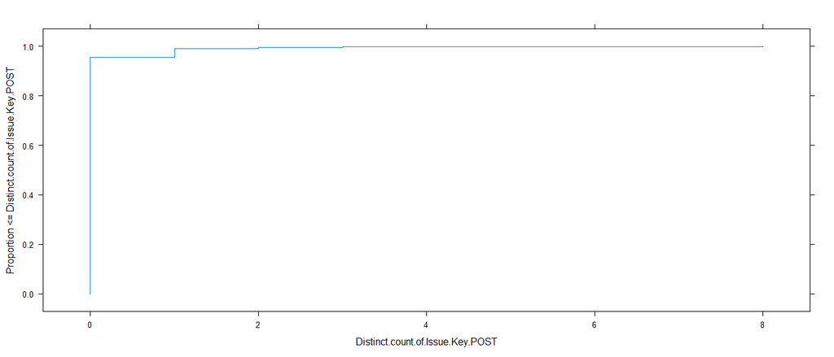

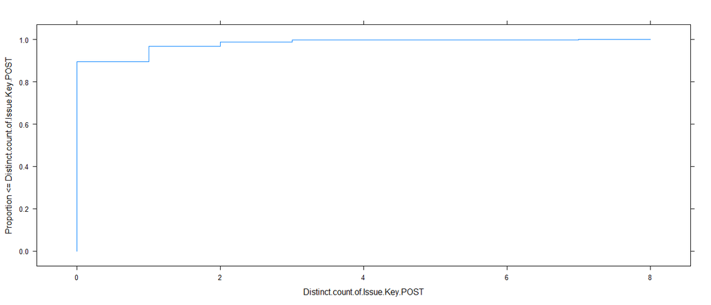

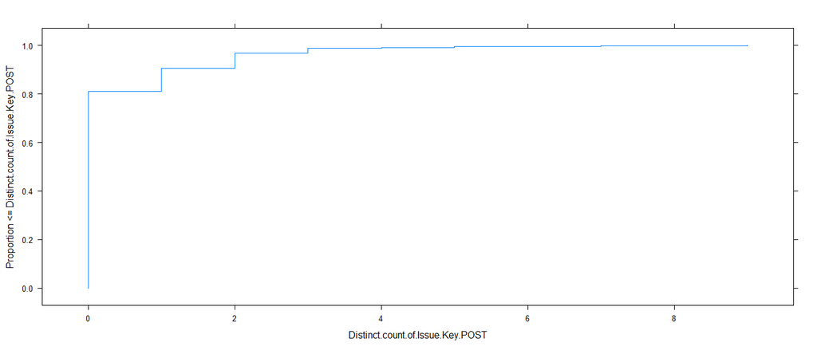

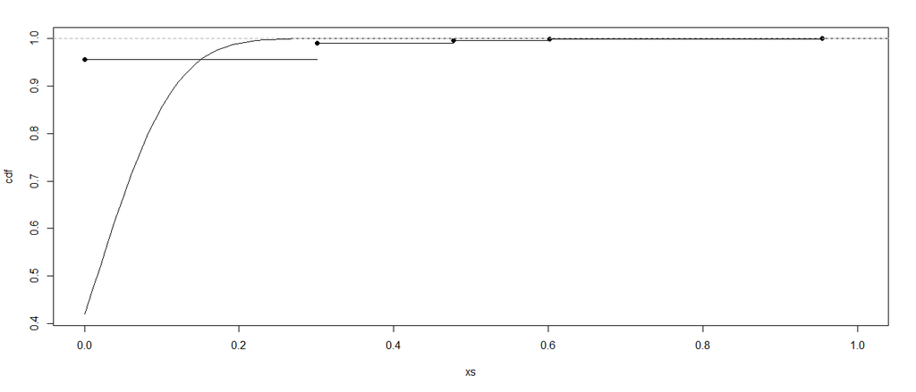

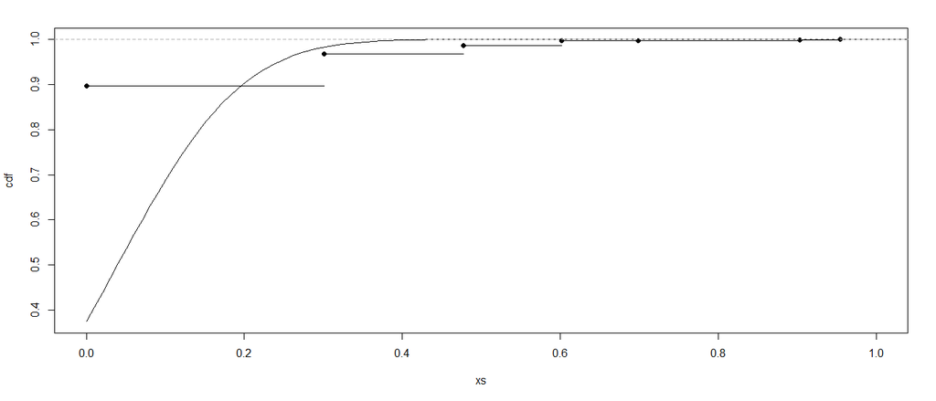

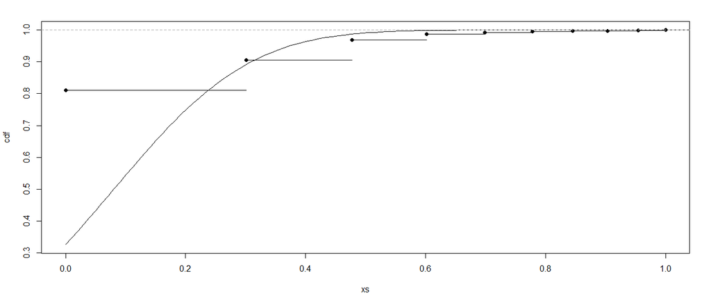

```r
modelSelectionAndNormalityAdjustment(all_list_omitted)
```

## Model 0 - BASE Only

### Drop variables

```r
all_list_omitted_m0 = vector("list", 0)
for (i in 1:length(projects)) {
  print(paste("Project:", projects[i]))
  temp_data = as.data.frame(all_list_omitted[[i]]$data)

  keepForID = c("Project", "File.Path")
  keepForCatch = c(keepForID)
  keepForTry = c(keepForID)
  keepForThrows = c(keepForID)

  catch_names_drop = catch_names[!(catch_names %in% keepForCatch)]
  try_names_drop = try_names[!(try_names %in% keepForTry)]
  throws_names_drop = throws_names[!(throws_names %in% keepForThrows)]

  temp_data = temp_data[,!(names(temp_data) %in% catch_names_drop)]
  temp_data = temp_data[,!(names(temp_data) %in% try_names_drop)]
  temp_data = temp_data[,!(names(temp_data) %in% throws_names_drop)]

  print(names(temp_data))

  all_list_omitted_m0 <- c(all_list_omitted_m0, list(temp_data))
}
```

```
[1] "Project: Jmeter"
 [1] "File.Path"                          "Distinct.count.of.Issue.Key.POST"
 [3] "Distinct.count.of.Issue.Key.PRE"    "Churn.PRE"
 [5] "Distinct.count.of.Author.Email.PRE" "Distinct.count.of.Commit.Hash.PRE"
 [7] "Kind"                               "File"
 [9] "AvgCyclomatic"                      "AvgCyclomaticModified"
[11] "AvgCyclomaticStrict"                "AvgEssential"
[13] "AvgLine"                            "AvgLineBlank"
[15] "AvgLineCode"                        "AvgLineComment"
[17] "CountDeclClass"                     "CountDeclClassMethod"
[19] "CountDeclClassVariable"             "CountDeclExecutableUnit"
[21] "CountDeclFunction"                  "CountDeclInstanceMethod"
[23] "CountDeclInstanceVariable"          "CountDeclMethod"
[25] "CountDeclMethodDefault"             "CountDeclMethodPrivate"
[27] "CountDeclMethodProtected"           "CountDeclMethodPublic"
```

[output cut: 63 more lines]

### Correlation analysis (MC4), Redundancy Analysis (MC5), Budget based correlation analysis (MC6)

```
[1] "Project: Jmeter"
[1] "NumberOfMetricsInitial: 44"
[1] "NumberOfMetricsKept: 14"
[1] "Distinct.count.of.Issue.Key.PRE + Churn.PRE + Distinct.count.of.Commit.Hash.PRE + AvgEssential + AvgLineBlank + AvgLineComment + CountDeclClass + CountDeclClassMethod + CountDeclClassVariable + CountDeclInstanceVariable + CountDeclMethodDefault + CountDeclMethodPrivate + CountDeclMethodProtecte…
[1] "Project: Cassandra"
```

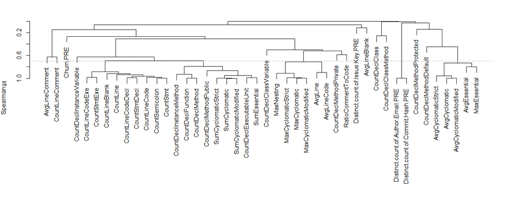

```
[1] "NumberOfMetricsInitial: 44"
[1] "NumberOfMetricsKept: 17"
[1] "Distinct.count.of.Issue.Key.PRE + Distinct.count.of.Commit.Hash.PRE + AvgCyclomaticModified + AvgEssential + AvgLineBlank + AvgLineComment + CountDeclClass + CountDeclClassMethod + CountDeclClassVariable + CountDeclInstanceMethod + CountDeclInstanceVariable + CountDeclMethodDefault + CountDeclM…
[1] "Project: Calcite"
```

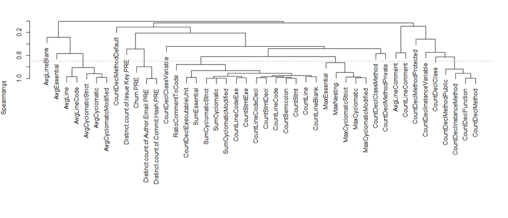

```
[1] "NumberOfMetricsInitial: 44"
[1] "NumberOfMetricsKept: 15"
[1] "Distinct.count.of.Issue.Key.PRE + Churn.PRE + Distinct.count.of.Author.Email.PRE + AvgEssential + AvgLineBlank + AvgLineComment + CountDeclClass + CountDeclClassMethod + CountDeclClassVariable + CountDeclInstanceMethod + CountDeclInstanceVariable + CountDeclMethodDefault + CountDeclMethodPrivat…
[1] "Project: Jmeter"
[1] "Redudant variables: "
[1] "File.Path + Distinct.count.of.Issue.Key.POST + Distinct.count.of.Issue.Key.PRE + Churn.PRE + Distinct.count.of.Commit.Hash.PRE + Kind + File + AvgEssential + AvgLineBlank + AvgLineComment + CountDeclClass + CountDeclClassMethod + CountDeclClassVariable + CountDeclInstanceVariable + CountDeclMet…
[1] "Project: Cassandra"
[1] "Redudant variables: "
[1] "File.Path + Distinct.count.of.Issue.Key.POST + Distinct.count.of.Issue.Key.PRE + Distinct.count.of.Commit.Hash.PRE + Kind + File + AvgCyclomaticModified + AvgEssential + AvgLineBlank + AvgLineComment + CountDeclClass + CountDeclClassMethod + CountDeclClassVariable + CountDeclInstanceMethod + Co…
[1] "Project: Calcite"
[1] "Redudant variables: "
[1] "File.Path + Distinct.count.of.Issue.Key.POST + Distinct.count.of.Issue.Key.PRE + Churn.PRE + Distinct.count.of.Author.Email.PRE + Kind + File + AvgEssential + AvgLineBlank + AvgLineComment + CountDeclClass + CountDeclClassMethod + CountDeclClassVariable + CountDeclInstanceMethod + CountDeclInst…
[1] "Project: Jmeter"
[1] "NumberOfMetricsInitial: 14 Budget: 55 Over Budget: FALSE NumberOfMetricsKept: 14 CorrelationCutoff: 0.7"
[1] "Project: Cassandra"
[1] "NumberOfMetricsInitial: 17 Budget: 86 Over Budget: FALSE NumberOfMetricsKept: 17 CorrelationCutoff: 0.7"
[1] "Project: Calcite"
[1] "NumberOfMetricsInitial: 15 Budget: 97 Over Budget: FALSE NumberOfMetricsKept: 15 CorrelationCutoff: 0.7"
```

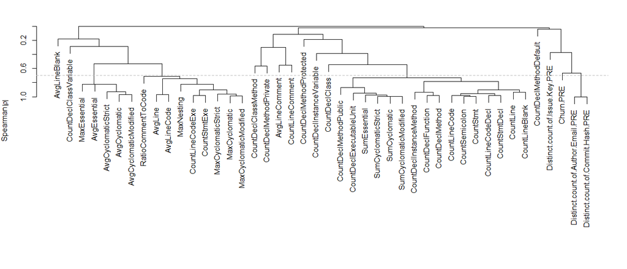

```r
all_list_model_m0 = dataApplyReduction(all_list_omitted_m0)
```

### Setup formulas

```r
form_list_bin_m0 = dataSetupFormulasBinary(all_list_model_m0)
```

```
[1] "Project: Jmeter"
[1] "Distinct.count.of.Issue.Key.PRE + Churn.PRE + Distinct.count.of.Commit.Hash.PRE + AvgEssential + AvgLineBlank + AvgLineComment + CountDeclClass + CountDeclClassMethod + CountDeclClassVariable + CountDeclInstanceVariable + CountDeclMethodDefault + CountDeclMethodPrivate + CountDeclMethodProtecte…
[1] "Project: Cassandra"
[1] "Distinct.count.of.Issue.Key.PRE + Distinct.count.of.Commit.Hash.PRE + AvgCyclomaticModified + AvgEssential + AvgLineBlank + AvgLineComment + CountDeclClass + CountDeclClassMethod + CountDeclClassVariable + CountDeclInstanceMethod + CountDeclInstanceVariable + CountDeclMethodDefault + CountDeclM…
[1] "Project: Calcite"
[1] "Distinct.count.of.Issue.Key.PRE + Churn.PRE + Distinct.count.of.Author.Email.PRE + AvgEssential + AvgLineBlank + AvgLineComment + CountDeclClass + CountDeclClassMethod + CountDeclClassVariable + CountDeclInstanceMethod + CountDeclInstanceVariable + CountDeclMethodDefault + CountDeclMethodPrivat…
```

### Fit regression model (MC7)

```r
models_2_BASE = modelFitLogistic(all_list_model_m0,form_list_bin_m0,"CAT.BASE")
```

```
[1] "Project: Jmeter"
Logistic Regression Model

 lrm(formula = as.formula(form_bin), data = temp_data_log, x = T,
     y = T)

                        Model Likelihood    Discrimination    Rank Discrim.
                              Ratio Test           Indexes          Indexes
 Obs           828    LR chi2     151.29    R2       0.546    C       0.950
  FALSE        791    d.f.            14    g        1.905    Dxy     0.901
  TRUE          37    Pr(> chi2) <0.0001    gr       6.717    gamma   0.902
 max |deriv| 7e-06                          gp       0.075    tau-a   0.077
                                            Brier    0.025

                                   Coef    S.E.   Wald Z Pr(>|Z|)
 Intercept                         -5.5262 3.0355 -1.82  0.0687
 Distinct.count.of.Issue.Key.PRE    2.9349 2.1029  1.40  0.1628
 Churn.PRE                          3.3785 0.4752  7.11  <0.0001
 Distinct.count.of.Commit.Hash.PRE -1.7222 3.7098 -0.46  0.6425
 AvgEssential                       3.7919 5.0140  0.76  0.4495
 AvgLineBlank                      -6.5277 2.5457 -2.56  0.0103
 AvgLineComment                     0.4738 1.2994  0.36  0.7154
 CountDeclClass                     1.5202 2.3811  0.64  0.5232
 CountDeclClassMethod               0.6690 0.9343  0.72  0.4739
 CountDeclClassVariable            -0.2929 0.8012 -0.37  0.7147
 CountDeclInstanceVariable         -0.5374 0.8186 -0.66  0.5115
 CountDeclMethodDefault             0.9239 1.5761  0.59  0.5578
 CountDeclMethodPrivate             0.9575 0.9243  1.04  0.3002
 CountDeclMethodProtected           2.4600 0.7900  3.11  0.0018
 CountLineComment                  -0.6685 1.6063 -0.42  0.6773

[1] "Project: Cassandra"
Logistic Regression Model

 lrm(formula = as.formula(form_bin), data = temp_data_log, x = T,
     y = T)

                        Model Likelihood    Discrimination    Rank Discrim.
                              Ratio Test           Indexes          Indexes
 Obs          1293    LR chi2     176.99    R2       0.263    C       0.812
```

[output cut: 41 more lines]

```
 Distinct.count.of.Issue.Key.PRE     2.0832 0.6109  3.41  0.0006
 Churn.PRE                           0.2929 0.1963  1.49  0.1356
 Distinct.count.of.Author.Email.PRE -0.4584 0.7443 -0.62  0.5380
 AvgEssential                        0.7070 0.8089  0.87  0.3821
 AvgLineBlank                        3.0685 0.6474  4.74  <0.0001
 AvgLineComment                      0.7861 0.3880  2.03  0.0427
 CountDeclClass                     -0.0113 0.5461 -0.02  0.9834
 CountDeclClassMethod               -0.2355 0.3092 -0.76  0.4462
 CountDeclClassVariable              2.1916 0.3491  6.28  <0.0001
 CountDeclInstanceMethod             1.3548 0.3133  4.32  <0.0001
 CountDeclInstanceVariable          -0.7200 0.2491 -2.89  0.0039
 CountDeclMethodDefault             -0.3634 0.2995 -1.21  0.2250
 CountDeclMethodPrivate              0.3437 0.3476  0.99  0.3227
 CountDeclMethodProtected           -0.2860 0.4181 -0.68  0.4938
 CountLineComment                    0.9796 0.4937  1.98  0.0472
```

### Model Analysis for BASE

In this section, we present the selected statistics for our analysis. As explained in our approach, they are the steps: MC7, MA1, MA2, MA3 and MA4.

Here we extract the selected statistics and we add the data (columns) to an object that will be exported to CSV in the section Output.

#### Fit regression model (MC7): summary stats

```r
model_things_2_BASE = vector("list", 0)
model_things_2_BASE = modelStats(models_2_BASE)
```

#### Model stability assessment (MA1)

```r
model_things_2_BASE = modelValidate(models_2_BASE, model_things_2_BASE)
```

```
Divergence or singularity in 6 samples
```

#### Model significant variables

```r
model_things_2_BASE = modelSignificance(models_2_BASE, model_things_2_BASE)
```

```
[1] "project:  Jmeter model:  CAT.BASE"
                Wald Statistics          Response: Distinct.count.of.Issue.Key.POST > 0

 Factor                            Chi-Square d.f. P
 Distinct.count.of.Issue.Key.PRE    1.95       1   0.1628
 Churn.PRE                         50.54       1   <.0001
 Distinct.count.of.Commit.Hash.PRE  0.22       1   0.6425
 AvgEssential                       0.57       1   0.4495
 AvgLineBlank                       6.58       1   0.0103
 AvgLineComment                     0.13       1   0.7154
 CountDeclClass                     0.41       1   0.5232
 CountDeclClassMethod               0.51       1   0.4739
 CountDeclClassVariable             0.13       1   0.7147
 CountDeclInstanceVariable          0.43       1   0.5115
 CountDeclMethodDefault             0.34       1   0.5578
 CountDeclMethodPrivate             1.07       1   0.3002
 CountDeclMethodProtected           9.70       1   0.0018
 CountLineComment                   0.17       1   0.6773
 TOTAL                             80.70      14   <.0001
[1] "project:  Cassandra model:  CAT.BASE"
                Wald Statistics          Response: Distinct.count.of.Issue.Key.POST > 0

 Factor                            Chi-Square d.f. P
 Distinct.count.of.Issue.Key.PRE     3.38      1   0.0661
 Distinct.count.of.Commit.Hash.PRE   4.30      1   0.0381
 AvgCyclomaticModified               2.77      1   0.0962
 AvgEssential                        1.26      1   0.2613
 AvgLineBlank                        5.18      1   0.0228
 AvgLineComment                      0.04      1   0.8502
 CountDeclClass                      1.24      1   0.2659
 CountDeclClassMethod                0.25      1   0.6199
 CountDeclClassVariable              9.33      1   0.0023
 CountDeclInstanceMethod             1.20      1   0.2732
 CountDeclInstanceVariable           1.17      1   0.2799
 CountDeclMethodDefault              1.49      1   0.2219
 CountDeclMethodPrivate              0.95      1   0.3294
 CountDeclMethodProtected            2.95      1   0.0858
 CountLineComment                    3.71      1   0.0540
 MaxEssential                        1.31      1   0.2517
 RatioCommentToCode                  4.41      1   0.0356
 TOTAL                             134.92     17   <.0001
[1] "project:  Calcite model:  CAT.BASE"
                Wald Statistics          Response: Distinct.count.of.Issue.Key.POST > 0

 Factor                             Chi-Square d.f. P
 Distinct.count.of.Issue.Key.PRE     11.63      1   0.0006
 Churn.PRE                            2.23      1   0.1356
 Distinct.count.of.Author.Email.PRE   0.38      1   0.5380
 AvgEssential                         0.76      1   0.3821
 AvgLineBlank                        22.46      1   <.0001
 AvgLineComment                       4.11      1   0.0427
 CountDeclClass                       0.00      1   0.9834
 CountDeclClassMethod                 0.58      1   0.4462
 CountDeclClassVariable              39.41      1   <.0001
 CountDeclInstanceMethod             18.70      1   <.0001
 CountDeclInstanceVariable            8.35      1   0.0039
 CountDeclMethodDefault               1.47      1   0.2250
 CountDeclMethodPrivate               0.98      1   0.3227
 CountDeclMethodProtected             0.47      1   0.4938
 CountLineComment                     3.94      1   0.0472
 TOTAL                              242.22     15   <.0001
```

#### Model simplification (MA2), Predictors’ explanatory power estimation (MA3), Predictors’ effect in the outcome measurement (MA4)

```r
model_things_2_BASE = modelSimplification(models_2_BASE, model_things_2_BASE)
```

```
[1] "project:  Jmeter model:  CAT.BASE Refit"
Logistic Regression Model

 lrm(formula = as.formula(final_form), data = temp_data, x = T,
     y = T)

                        Model Likelihood    Discrimination    Rank Discrim.
                              Ratio Test           Indexes          Indexes
 Obs           828    LR chi2     143.69    R2       0.521    C       0.945
  FALSE        791    d.f.             3    g        1.538    Dxy     0.891
  TRUE          37    Pr(> chi2) <0.0001    gr       4.654    gamma   0.910
 max |deriv| 5e-08                          gp       0.073    tau-a   0.076
                                            Brier    0.026

                          Coef    S.E.   Wald Z Pr(>|Z|)
 Intercept                -5.2293 0.4309 -12.13 <0.0001
 Churn.PRE                 3.5560 0.4052   8.78 <0.0001
 AvgLineBlank             -5.0293 2.1407  -2.35 0.0188
 CountDeclMethodProtected  2.0703 0.6234   3.32 0.0009

[1] "project:  Jmeter model:  CAT.BASE Refit - summary"
[1] "project:  Jmeter model:  CAT.BASE Refit - validate"
[1] "project:  Jmeter model:  CAT.BASE Refit - anova"
                Wald Statistics          Response: Distinct.count.of.Issue.Key.POST > 0

 Factor                   Chi-Square d.f. P
 Churn.PRE                77.03      1    <.0001
 AvgLineBlank              5.52      1    0.0188
 CountDeclMethodProtected 11.03      1    0.0009
 TOTAL                    84.30      3    <.0001
[1] "Churn.PRE"
[1] "AvgLineBlank"
[1] "CountDeclMethodProtected"
```

| Churn.PRE | AvgLineBlank | CountDeclMethodProtected |
| --- | --- | --- |
| 2.727053 | 0.2173913 | 0.5422705 |

```
[1] "Fixed at Mean: 0.0377754505727432"
[1] "Churn.PRE  Coef at Mean + 10%: 0.041945555638496"
[1] "AvgLineBlank  Coef at Mean + 10%: 0.0363950742651731"
[1] "CountDeclMethodProtected  Coef at Mean + 10%: 0.0389211520034613"
[1] "project:  Cassandra model:  CAT.BASE Refit"
Logistic Regression Model

 lrm(formula = as.formula(final_form), data = temp_data, x = T,
     y = T)

                        Model Likelihood    Discrimination    Rank Discrim.
                              Ratio Test           Indexes          Indexes
 Obs          1293    LR chi2     158.23    R2       0.237    C       0.797
  FALSE       1159    d.f.             4    g        1.383    Dxy     0.593
  TRUE         134    Pr(> chi2) <0.0001    gr       3.988    gamma   0.593
 max |deriv| 4e-11                          gp       0.111    tau-a   0.110
                                            Brier    0.078

                                   Coef    S.E.   Wald Z Pr(>|Z|)
 Intercept                         -4.7546 0.5160 -9.21  <0.0001
 Distinct.count.of.Commit.Hash.PRE  2.5050 0.7561  3.31  0.0009
 CountDeclClassVariable             0.9620 0.3100  3.10  0.0019
 CountLineComment                   1.7088 0.3286  5.20  <0.0001
 RatioCommentToCode                -4.0414 1.1475 -3.52  0.0004

[1] "project:  Cassandra model:  CAT.BASE Refit - summary"
[1] "project:  Cassandra model:  CAT.BASE Refit - validate"
[1] "project:  Cassandra model:  CAT.BASE Refit - anova"
                Wald Statistics          Response: Distinct.count.of.Issue.Key.POST > 0

 Factor                            Chi-Square d.f. P
 Distinct.count.of.Commit.Hash.PRE  10.98     1    0.0009
 CountDeclClassVariable              9.63     1    0.0019
 CountLineComment                   27.04     1    <.0001
 RatioCommentToCode                 12.40     1    0.0004
 TOTAL                             124.24     4    <.0001
[1] "Distinct.count.of.Commit.Hash.PRE"
[1] "CountDeclClassVariable"
[1] "CountLineComment"
[1] "RatioCommentToCode"
```

| Distinct.count.of.Commit.Hash.PRE | CountDeclClassVariable | CountLineComment | RatioCommentToCode |
| --- | --- | --- | --- |
| 0.1500387 | 1.576953 | 43.22042 | 0.8585228 |

```
[1] "Fixed at Mean: 0.0770787415774354"
[1] "Distinct.count.of.Commit.Hash.PRE  Coef at Mean + 10%: 0.0780878841067753"
[1] "CountDeclClassVariable  Coef at Mean + 10%: 0.0788627233960897"
[1] "CountLineComment  Coef at Mean + 10%: 0.0821482722124231"
[1] "RatioCommentToCode  Coef at Mean + 10%: 0.0716260143964796"
[1] "project:  Calcite model:  CAT.BASE Refit"
Logistic Regression Model

 lrm(formula = as.formula(final_form), data = temp_data, x = T,
     y = T)

                        Model Likelihood    Discrimination    Rank Discrim.
                              Ratio Test           Indexes          Indexes
 Obs          1460    LR chi2     356.43    R2       0.349    C       0.837
  FALSE       1184    d.f.             6    g        1.457    Dxy     0.674
  TRUE         276    Pr(> chi2) <0.0001    gr       4.292    gamma   0.676
 max |deriv| 2e-10                          gp       0.196    tau-a   0.207
                                            Brier    0.113

                                 Coef    S.E.   Wald Z Pr(>|Z|)
 Intercept                       -3.6446 0.2102 -17.34 <0.0001
 Distinct.count.of.Issue.Key.PRE  2.5696 0.5199   4.94 <0.0001
 AvgLineBlank                     3.1879 0.6013   5.30 <0.0001
 AvgLineComment                   1.4071 0.2811   5.01 <0.0001
 CountDeclClassVariable           2.4615 0.3180   7.74 <0.0001
 CountDeclInstanceMethod          1.6546 0.2308   7.17 <0.0001
 CountDeclInstanceVariable       -0.6117 0.2279  -2.68 0.0073

[1] "project:  Calcite model:  CAT.BASE Refit - summary"
[1] "project:  Calcite model:  CAT.BASE Refit - validate"
[1] "project:  Calcite model:  CAT.BASE Refit - anova"
                Wald Statistics          Response: Distinct.count.of.Issue.Key.POST > 0

 Factor                          Chi-Square d.f. P
 Distinct.count.of.Issue.Key.PRE  24.43     1    <.0001
 AvgLineBlank                     28.11     1    <.0001
 AvgLineComment                   25.06     1    <.0001
 CountDeclClassVariable           59.92     1    <.0001
 CountDeclInstanceMethod          51.40     1    <.0001
 CountDeclInstanceVariable         7.20     1    0.0073
 TOTAL                           239.16     6    <.0001
[1] "Distinct.count.of.Issue.Key.PRE"
[1] "AvgLineBlank"
[1] "AvgLineComment"
[1] "CountDeclClassVariable"
[1] "CountDeclInstanceMethod"
[1] "CountDeclInstanceVariable"
```

| Distinct.count.of.Issue.Key.PRE | AvgLineBlank | AvgLineComment | CountDeclClassVariable | CountDeclInstanceMethod | CountDeclInstanceVariable |
| --- | --- | --- | --- | --- | --- |
| 0.1958904 | 0.1342466 | 1.034932 | 0.8547945 | 8.587671 | 2.817808 |

```
[1] "Fixed at Mean: 0.287497849556867"
[1] "Distinct.count.of.Issue.Key.PRE  Coef at Mean + 10%: 0.291226309899571"
[1] "AvgLineBlank  Coef at Mean + 10%: 0.29084631984034"
[1] "AvgLineComment  Coef at Mean + 10%: 0.293747612148684"
[1] "CountDeclClassVariable  Coef at Mean + 10%: 0.297463990126818"
[1] "CountDeclInstanceMethod  Coef at Mean + 10%: 0.300288100997195"
[1] "CountDeclInstanceVariable  Coef at Mean + 10%: 0.283638450902878"
```

### Model 2 - Extension: BASE + EH Catch

```r
all_list_omitted_m2 = all_list_omitted
```

#### Drop variables - adjust metric sets

To be able to build new models that are an extension of the base model we removed all insignificant metrics according to the related base model construction. This process makes sense since one can adjust metrics based on expertise. In this case, we learned in the previous step what are the significant metrics for base only, therefore we can remove the other base metrics. In this process we need to loop through each model previously built. Each model can have a different set of metrics and, therefore, the construction of their extensions have to be separately done.

```r
all_list_omitted_m2 = vector("list", 0)

for (i in 1:length(models_2_BASE)) {
  name = models_2_BASE[[i]]$name
  project = models_2_BASE[[i]]$project
  fit = models_2_BASE[[i]]$fit
  class = as.character(class(fit)[1])
  print(paste("Project:", project, "Name:", name))

  if(class != "try-error") {

    temp_data_index = findProjectData(all_list_omitted,project)
    temp_data = as.data.frame(all_list_omitted[[temp_data_index]]$data)

    # Keep catch metrics, remove try and throws, adjust base.
    keepForID = c("Project", "File.Path")
    keepForBase = c("Distinct.count.of.Issue.Key.POST",keepForID)
    keepForTry = c(keepForID)
    keepForThrows = c(keepForID)

    base_names_drop = base_names[!(base_names %in% keepForBase)]
    try_names_drop = try_names[!(try_names %in% keepForTry)]
    throws_names_drop = throws_names[!(throws_names %in% keepForThrows)]

    temp_data = temp_data[,!(names(temp_data) %in% try_names_drop)]
    temp_data = temp_data[,!(names(temp_data) %in% throws_names_drop)]

    # Remove insignificant metrics according to related base model.
    temp_sig_index = findModel(model_things_2_BASE,name,project)

    # Only move forward with the models that are under budget.
    if (!model_things_2_BASE[[temp_sig_index]][["over_budget"]]){
      temp_significant = model_things_2_BASE[[temp_sig_index]][["signifcant_r"]]
      if (!is.na(temp_significant)) {
        # The significant metrics from the base model as a vector of char.
        temp_significant_list = unlist(strsplit(temp_significant, ", "))
      } else
        temp_significant_list = unlist(strsplit("", ", "))

      # The insignificant metrics: all from the base model minus the significant ones.
      base_names_insignificant = base_names_drop[!(base_names_drop %in% temp_significant_list)]
      # The clean list of metrics for modeling: all metrics minus the base insignificant ones.
      temp_data = temp_data[,!(names(temp_data) %in% base_names_insignificant)]
      print(names(temp_data))

      all_list_omitted_m2 <- c(all_list_omitted_m2, list(list(name=name, project=project, data=temp_data, sig=temp_significant_list)))
    } else
      print(paste("!-ERROR-! - model over budget."))

  } else
    print(paste("!-ERROR-! - model construction had issues."))
}
```

```
[1] "Project: Jmeter Name: CAT.BASE"
 [1] "File.Path"                              "Distinct.count.of.Issue.Key.POST"
 [3] "Churn.PRE"                              "AvgLineBlank"
 [5] "CountDeclMethodProtected"               "CatchSLOC"
 [7] "CatchLOC"                               "Avg.Catch.LOC"
 [9] "Avg.Catch.SLOC"                         "AP.Catch.and.do.nothing"
[11] "Avg..AP.Catch.and.do.nothing"           "Sum.of.AP.Destructive.Wrapping"
[13] "Avg..AP.Destructive.Wrapping"           "Sum.of.AP.Dummy.Handler"
[15] "Avg..AP.Dummy.Handler"                  "AP.Incomplete.implementation"
[17] "Avg..AP.Incomplete.implementation"      "AP.Ignoring.Interrupted.Exception"
[19] "Avg..AP.Ignoring.Interrupted.Exception" "Sum.of.AP.Log.and.Return.null"
[21] "Avg..AP.Log.and.Return.null"            "AP.Log.and.Throw"
[23] "Avg..AP.Log.and.Throw"                  "AP.Multi.line.log.messages"
[25] "Avg..AP.Multi.line.log.messages"        "AP.Nested.try.block"
[27] "Avg..AP.Nested.try.block"               "AP.Relying.on.getCause.."
```

[output cut: 66 more lines]

```r
dropToPredict = c("File.Path",  "Project", "Language", "Table.Name","Name","Kind", "X..Bugs.Post", "File", "Distinct.count.of.Issue.Key.POST")
```

#### Correlation analysis (MC4), Redundancy Analysis (MC5), Budget based correlation analysis (MC6)

```
[1] "Project: Jmeter Name: CAT.BASE"
[1] "NumberOfMetricsInitial: 48"
[1] "NumberOfMetricsKept: 4"
[1] "Churn.PRE + AvgLineBlank + CountDeclMethodProtected + Avg..Potentially.Recoverable"
[1] "File.Path"                        "Distinct.count.of.Issue.Key.POST"
[3] "Churn.PRE"                        "AvgLineBlank"
[5] "CountDeclMethodProtected"         "Avg..Potentially.Recoverable"
[1] "Project: Cassandra Name: CAT.BASE"
```

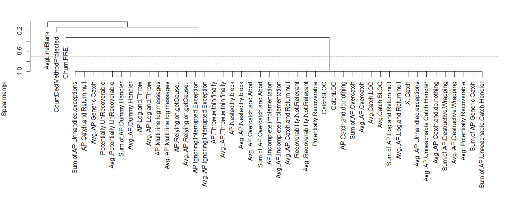

```
[1] "NumberOfMetricsInitial: 49"
[1] "NumberOfMetricsKept: 5"
[1] "Distinct.count.of.Commit.Hash.PRE + CountDeclClassVariable + CountLineComment + RatioCommentToCode + Avg..AP.Destructive.Wrapping"
[1] "File.Path"                         "Distinct.count.of.Issue.Key.POST"
[3] "Distinct.count.of.Commit.Hash.PRE" "CountDeclClassVariable"
[5] "CountLineComment"                  "RatioCommentToCode"
[7] "Avg..AP.Destructive.Wrapping"
[1] "Project: Calcite Name: CAT.BASE"
```

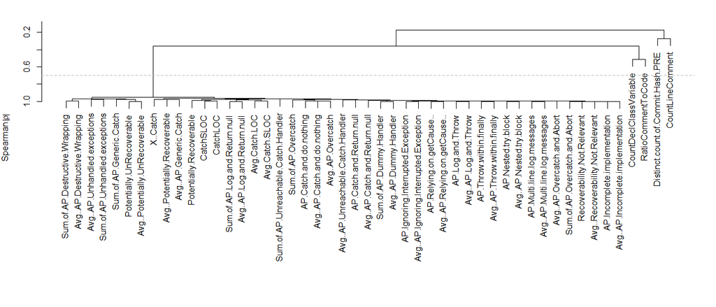

```
[1] "NumberOfMetricsInitial: 51"
[1] "NumberOfMetricsKept: 6"
[1] "Distinct.count.of.Issue.Key.PRE + AvgLineBlank + AvgLineComment + CountDeclClassVariable + CountDeclInstanceMethod + CountDeclInstanceVariable"
[1] "File.Path"                        "Distinct.count.of.Issue.Key.POST"
[3] "Distinct.count.of.Issue.Key.PRE"  "AvgLineBlank"
[5] "AvgLineComment"                   "CountDeclClassVariable"
[7] "CountDeclInstanceMethod"          "CountDeclInstanceVariable"
[1] "Project: Jmeter Name: CAT.BASE"
[1] "Redudant variables: "
[1] "Final variables: File.Path + Distinct.count.of.Issue.Key.POST + Churn.PRE + AvgLineBlank + CountDeclMethodProtected + Avg..Potentially.Recoverable"
[1] "NumberOfMetricsInitial: 6"
[1] "NumberOfMetricsKept: 6"
[1] "Project: Cassandra Name: CAT.BASE"
[1] "Redudant variables: "
[1] "Final variables: File.Path + Distinct.count.of.Issue.Key.POST + Distinct.count.of.Commit.Hash.PRE + CountDeclClassVariable + CountLineComment + RatioCommentToCode + Avg..AP.Destructive.Wrapping"
```

[output cut: 16 more lines]

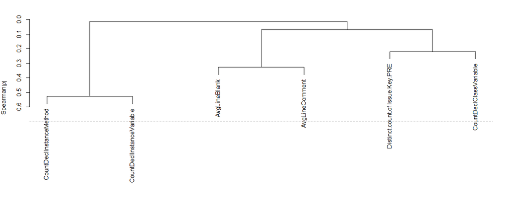

```r
all_list_model_m2 = dataApplyReductionByModel(all_list_omitted_m2, "BSAP")
```

#### Setup formulas

```r
form_list_bin_m2 = dataSetupFormulasBinaryByModel(all_list_model_m2)
```

```
[1] "Project: Jmeter Name: CAT.BASE"
[1] "Churn.PRE + AvgLineBlank + CountDeclMethodProtected + Avg..Potentially.Recoverable"
[1] "Project: Cassandra Name: CAT.BASE"
[1] "Distinct.count.of.Commit.Hash.PRE + CountDeclClassVariable + CountLineComment + RatioCommentToCode + Avg..AP.Destructive.Wrapping"
[1] "Project: Calcite Name: CAT.BASE"
[1] "Distinct.count.of.Issue.Key.PRE + AvgLineBlank + AvgLineComment + CountDeclClassVariable + CountDeclInstanceMethod + CountDeclInstanceVariable"
```

#### Fit regression model (MC7)

```r
models_2_BSAP = modelFitLogisticByModel(all_list_model_m2,form_list_bin_m2,"CAT.BSAP")
```

```
[1] "Project: Jmeter Name: CAT.BASE"
[1] "Error in fitter(X, Y, offset = offs, penalty.matrix = penalty.matrix,  : \n  NA/NaN/Inf in foreign function call (arg 4)\n"
attr(,"class")
[1] "try-error"
attr(,"condition")
<simpleError in fitter(X, Y, offset = offs, penalty.matrix = penalty.matrix,     tol = tol, weights = weights, normwt = normwt, scale = scale,     ...): NA/NaN/Inf in foreign function call (arg 4)>
[1] "Project: Cassandra Name: CAT.BASE"
[1] "Error in fitter(X, Y, offset = offs, penalty.matrix = penalty.matrix,  : \n  NA/NaN/Inf in foreign function call (arg 4)\n"
attr(,"class")
[1] "try-error"
attr(,"condition")
<simpleError in fitter(X, Y, offset = offs, penalty.matrix = penalty.matrix,     tol = tol, weights = weights, normwt = normwt, scale = scale,     ...): NA/NaN/Inf in foreign function call (arg 4)>
[1] "Project: Calcite Name: CAT.BASE"
Logistic Regression Model

 lrm(formula = as.formula(form_bin), data = temp_data_log, x = T,
     y = T)

                        Model Likelihood    Discrimination    Rank Discrim.
                              Ratio Test           Indexes          Indexes
 Obs          1460    LR chi2     356.43    R2       0.349    C       0.837
  FALSE       1184    d.f.             6    g        1.457    Dxy     0.674
  TRUE         276    Pr(> chi2) <0.0001    gr       4.292    gamma   0.676
 max |deriv| 2e-10                          gp       0.196    tau-a   0.207
                                            Brier    0.113

                                 Coef    S.E.   Wald Z Pr(>|Z|)
 Intercept                       -3.6446 0.2102 -17.34 <0.0001
 Distinct.count.of.Issue.Key.PRE  2.5696 0.5199   4.94 <0.0001
 AvgLineBlank                     3.1879 0.6013   5.30 <0.0001
 AvgLineComment                   1.4071 0.2811   5.01 <0.0001
 CountDeclClassVariable           2.4615 0.3180   7.74 <0.0001
 CountDeclInstanceMethod          1.6546 0.2308   7.17 <0.0001
 CountDeclInstanceVariable       -0.6117 0.2279  -2.68 0.0073
```

#### Model Analysis for BSAP

In this section, we present the selected statistics for our analysis. As explained in our approach, they are the steps: MC7, MA1, MA2, MA3 and MA4.

Here we extract the selected statistics and we add the data (columns) to an object that will be exported to CSV in the section Output.

##### Fit regression model (MC7): summary stats

```r
model_things_2_BSAP = vector("list", 0)
model_things_2_BSAP = modelStats(models_2_BSAP)
```

##### Model stability assessment (MA1)

```r
model_things_2_BSAP = modelValidate(models_2_BSAP, model_things_2_BSAP)
```

##### Model significant variables

```r
model_things_2_BSAP = modelSignificance(models_2_BSAP, model_things_2_BSAP)
```

```
[1] "project:  Calcite model:  CAT.BSAP"
                Wald Statistics          Response: Distinct.count.of.Issue.Key.POST > 0

 Factor                          Chi-Square d.f. P
 Distinct.count.of.Issue.Key.PRE  24.43     1    <.0001
 AvgLineBlank                     28.11     1    <.0001
 AvgLineComment                   25.06     1    <.0001
 CountDeclClassVariable           59.92     1    <.0001
 CountDeclInstanceMethod          51.40     1    <.0001
 CountDeclInstanceVariable         7.20     1    0.0073
 TOTAL                           239.16     6    <.0001
```

##### Model simplification (MA2), Predictors’ explanatory power estimation (MA3), Predictors’ effect in the outcome measurement (MA4)

```r
model_things_2_BSAP = modelSimplification(models_2_BSAP, model_things_2_BSAP)
```

```
[1] "project:  Jmeter model:  CAT.BSAP Refit"
[1] NA
[1] "project:  Cassandra model:  CAT.BSAP Refit"
[1] NA
[1] "project:  Calcite model:  CAT.BSAP Refit"
Logistic Regression Model

 lrm(formula = as.formula(final_form), data = temp_data, x = T,
     y = T)

                        Model Likelihood    Discrimination    Rank Discrim.
                              Ratio Test           Indexes          Indexes
 Obs          1460    LR chi2     356.43    R2       0.349    C       0.837
  FALSE       1184    d.f.             6    g        1.457    Dxy     0.674
  TRUE         276    Pr(> chi2) <0.0001    gr       4.292    gamma   0.676
 max |deriv| 2e-10                          gp       0.196    tau-a   0.207
                                            Brier    0.113

                                 Coef    S.E.   Wald Z Pr(>|Z|)
 Intercept                       -3.6446 0.2102 -17.34 <0.0001
 Distinct.count.of.Issue.Key.PRE  2.5696 0.5199   4.94 <0.0001
 AvgLineBlank                     3.1879 0.6013   5.30 <0.0001
 AvgLineComment                   1.4071 0.2811   5.01 <0.0001
 CountDeclClassVariable           2.4615 0.3180   7.74 <0.0001
 CountDeclInstanceMethod          1.6546 0.2308   7.17 <0.0001
 CountDeclInstanceVariable       -0.6117 0.2279  -2.68 0.0073

[1] "project:  Calcite model:  CAT.BSAP Refit - summary"
[1] "project:  Calcite model:  CAT.BSAP Refit - validate"
[1] "project:  Calcite model:  CAT.BSAP Refit - anova"
                Wald Statistics          Response: Distinct.count.of.Issue.Key.POST > 0

 Factor                          Chi-Square d.f. P
 Distinct.count.of.Issue.Key.PRE  24.43     1    <.0001
 AvgLineBlank                     28.11     1    <.0001
 AvgLineComment                   25.06     1    <.0001
 CountDeclClassVariable           59.92     1    <.0001
 CountDeclInstanceMethod          51.40     1    <.0001
 CountDeclInstanceVariable         7.20     1    0.0073
 TOTAL                           239.16     6    <.0001
[1] "Distinct.count.of.Issue.Key.PRE"
[1] "AvgLineBlank"
[1] "AvgLineComment"
[1] "CountDeclClassVariable"
[1] "CountDeclInstanceMethod"
[1] "CountDeclInstanceVariable"
```

| Distinct.count.of.Issue.Key.PRE | AvgLineBlank | AvgLineComment | CountDeclClassVariable | CountDeclInstanceMethod | CountDeclInstanceVariable |
| --- | --- | --- | --- | --- | --- |
| 0.1958904 | 0.1342466 | 1.034932 | 0.8547945 | 8.587671 | 2.817808 |

```
[1] "Fixed at Mean: 0.287497849556867"
[1] "Distinct.count.of.Issue.Key.PRE  Coef at Mean + 10%: 0.291226309899571"
[1] "AvgLineBlank  Coef at Mean + 10%: 0.29084631984034"
[1] "AvgLineComment  Coef at Mean + 10%: 0.293747612148684"
[1] "CountDeclClassVariable  Coef at Mean + 10%: 0.297463990126818"
[1] "CountDeclInstanceMethod  Coef at Mean + 10%: 0.300288100997195"
[1] "CountDeclInstanceVariable  Coef at Mean + 10%: 0.283638450902878"
```

### Model Extension: BASE + EH Try

```r
all_list_omitted_m3 = all_list_omitted
```

#### Drop variables - adjust metric sets

To be able to build new models that are an extension of the base model we removed all insignificant metrics according to the related base model construction. This process makes sense since one can adjust metrics based on expertise. In this case, we learned in the previous step what are the significant metrics for base only, therefore we can remove the other base metrics. In this process we need to loop through each model previously built. Each model can have a different set of metrics and, therefore, the construction of their extensions have to be separately done.

```r
all_list_omitted_m3 = vector("list", 0)

for (i in 1:length(models_2_BASE)) {
  name = models_2_BASE[[i]]$name
  project = models_2_BASE[[i]]$project
  fit = models_2_BASE[[i]]$fit
  class = as.character(class(fit)[1])
  print(paste("Project:", project, "Name:", name))

  if(class != "try-error") {

    temp_data_index = findProjectData(all_list_omitted,project)
    temp_data = as.data.frame(all_list_omitted[[temp_data_index]]$data)

    # Keep catch metrics, remove try and throws, adjust base.
    keepForID = c("Project", "File.Path")
    keepForBase = c("Distinct.count.of.Issue.Key.POST",keepForID)
    keepForCatch = c(keepForID)
    keepForThrows = c(keepForID)

    base_names_drop = base_names[!(base_names %in% keepForBase)]
    catch_names_drop = catch_names[!(catch_names %in% keepForCatch)]
    throws_names_drop = throws_names[!(throws_names %in% keepForThrows)]

    temp_data = temp_data[,!(names(temp_data) %in% catch_names_drop)]
    temp_data = temp_data[,!(names(temp_data) %in% throws_names_drop)]

    # Remove insignificant metrics according to related base model.
    temp_sig_index = findModel(model_things_2_BASE,name,project)

    # Only move forward with the models that are under budget.
    if (!model_things_2_BASE[[temp_sig_index]][["over_budget"]]){
      temp_significant = model_things_2_BASE[[temp_sig_index]][["signifcant_r"]]
      if (!is.na(temp_significant)) {
        # The significant metrics from the base model as a vector of char.
        temp_significant_list = unlist(strsplit(temp_significant, ", "))
      } else
        temp_significant_list = unlist(strsplit("", ", "))

      # The insignificant metrics: all from the base model minus the significant ones.
      base_names_insignificant = base_names_drop[!(base_names_drop %in% temp_significant_list)]
      # The clean list of metrics for modeling: all metrics minus the base insignificant ones.
      temp_data = temp_data[,!(names(temp_data) %in% base_names_insignificant)]
      print(names(temp_data))

      all_list_omitted_m3 <- c(all_list_omitted_m3, list(list(name=name, project=project, data=temp_data, sig=temp_significant_list)))
    } else
      print(paste("!-ERROR-! - model over budget."))

  } else
    print(paste("!-ERROR-! - model construction had issues."))
}
```

```
[1] "Project: Jmeter Name: CAT.BASE"
 [1] "File.Path"                                   "Distinct.count.of.Issue.Key.POST"
 [3] "Churn.PRE"                                   "AvgLineBlank"
 [5] "CountDeclMethodProtected"                    "Avg.Max.Depth"
 [7] "Avg.Depth"                                   "Avg.Try.SLOC"
 [9] "Avg.Try.LOC"                                 "Try.SLOC"
[11] "Try.LOC"                                     "X..Handled.with.Nested.Try"
[13] "X..Handled.with.Log"                         "X..Handled.with.Abort"
[15] "X..Handled.with.Default"                     "X..Handled.with.Method"
[17] "X..Handled.with.Throw.with.New"              "X..Handled.with.Throw.Wrap"
[19] "X..Handled.with.Return"                      "X..Handled.with.Continue"
[21] "X..Handled.with.Empty"                       "X..Handled.with.ToDo"
[23] "X..Handled.with.Throw.without.New"           "X..Handled.with.Nested.Try.1"
[25] "X..Handled.with.Log.1"                       "X..Handled.with.Abort.1"
[27] "X..Handled.with.Default.1"                   "X..Handled.with.Method.1"
```

[output cut: 84 more lines]

```r
dropToPredict = c("File.Path",  "Project", "Language", "Table.Name","Name","Kind", "X..Bugs.Post", "File", "Distinct.count.of.Issue.Key.POST")
```

#### Correlation analysis (MC4), Redundancy Analysis (MC5), Budget based correlation analysis (MC6)

[output not shown]

[figure not shown]

[output not shown]

[figure not shown]

```
[1] "NumberOfMetricsInitial: 51"
[1] "NumberOfMetricsKept: 6"
[1] "Distinct.count.of.Issue.Key.PRE + AvgLineBlank + AvgLineComment + CountDeclClassVariable + CountDeclInstanceMethod + CountDeclInstanceVariable"
[1] "File.Path"                        "Distinct.count.of.Issue.Key.POST"
[3] "Distinct.count.of.Issue.Key.PRE"  "AvgLineBlank"
[5] "AvgLineComment"                   "CountDeclClassVariable"
[7] "CountDeclInstanceMethod"          "CountDeclInstanceVariable"
[1] "Project: Jmeter Name: CAT.BASE"
[1] "Redudant variables: "
[1] "Final variables: File.Path + Distinct.count.of.Issue.Key.POST + Churn.PRE + AvgLineBlank + CountDeclMethodProtected + Avg..Potentially.Recoverable"
[1] "NumberOfMetricsInitial: 6"
[1] "NumberOfMetricsKept: 6"
[1] "Project: Cassandra Name: CAT.BASE"
[1] "Redudant variables: "
[1] "Final variables: File.Path + Distinct.count.of.Issue.Key.POST + Distinct.count.of.Commit.Hash.PRE + CountDeclClassVariable + CountLineComment + RatioCommentToCode + Avg..AP.Destructive.Wrapping"
```

[output cut: 16 more lines]

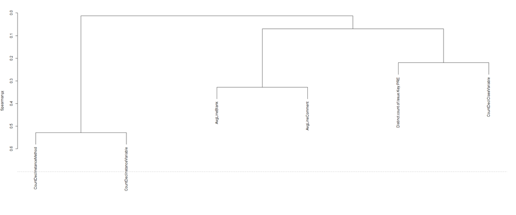

```r
all_list_model_m3 = dataApplyReductionByModel(all_list_omitted_m3, "BSFC")
```

#### Setup formulas

```r
form_list_bin_m3 = dataSetupFormulasBinaryByModel(all_list_model_m3)
```

```
[1] "Project: Jmeter Name: CAT.BASE"
[1] "Churn.PRE + AvgLineBlank + CountDeclMethodProtected + Avg..Potentially.Recoverable"
[1] "Project: Cassandra Name: CAT.BASE"
[1] "Distinct.count.of.Commit.Hash.PRE + CountDeclClassVariable + CountLineComment + RatioCommentToCode + Avg..AP.Destructive.Wrapping"
[1] "Project: Calcite Name: CAT.BASE"
[1] "Distinct.count.of.Issue.Key.PRE + AvgLineBlank + AvgLineComment + CountDeclClassVariable + CountDeclInstanceMethod + CountDeclInstanceVariable"
```

#### Fit regression model (MC7)

```r
models_2_BSFC = modelFitLogisticByModel(all_list_model_m3,form_list_bin_m3,"CAT.BSFC")
```

```
[1] "Project: Jmeter Name: CAT.BASE"
[1] "Error in fitter(X, Y, offset = offs, penalty.matrix = penalty.matrix,  : \n  NA/NaN/Inf in foreign function call (arg 4)\n"
attr(,"class")
[1] "try-error"
attr(,"condition")
<simpleError in fitter(X, Y, offset = offs, penalty.matrix = penalty.matrix,     tol = tol, weights = weights, normwt = normwt, scale = scale,     ...): NA/NaN/Inf in foreign function call (arg 4)>
[1] "Project: Cassandra Name: CAT.BASE"
[1] "Error in fitter(X, Y, offset = offs, penalty.matrix = penalty.matrix,  : \n  NA/NaN/Inf in foreign function call (arg 4)\n"
attr(,"class")
[1] "try-error"
attr(,"condition")
<simpleError in fitter(X, Y, offset = offs, penalty.matrix = penalty.matrix,     tol = tol, weights = weights, normwt = normwt, scale = scale,     ...): NA/NaN/Inf in foreign function call (arg 4)>
[1] "Project: Calcite Name: CAT.BASE"
Logistic Regression Model

 lrm(formula = as.formula(form_bin), data = temp_data_log, x = T,
     y = T)

                        Model Likelihood    Discrimination    Rank Discrim.
                              Ratio Test           Indexes          Indexes
 Obs          1460    LR chi2     356.43    R2       0.349    C       0.837
  FALSE       1184    d.f.             6    g        1.457    Dxy     0.674
  TRUE         276    Pr(> chi2) <0.0001    gr       4.292    gamma   0.676
 max |deriv| 2e-10                          gp       0.196    tau-a   0.207
                                            Brier    0.113

                                 Coef    S.E.   Wald Z Pr(>|Z|)
 Intercept                       -3.6446 0.2102 -17.34 <0.0001
 Distinct.count.of.Issue.Key.PRE  2.5696 0.5199   4.94 <0.0001
 AvgLineBlank                     3.1879 0.6013   5.30 <0.0001
 AvgLineComment                   1.4071 0.2811   5.01 <0.0001
 CountDeclClassVariable           2.4615 0.3180   7.74 <0.0001
 CountDeclInstanceMethod          1.6546 0.2308   7.17 <0.0001
 CountDeclInstanceVariable       -0.6117 0.2279  -2.68 0.0073
```

#### Model Analysis for BSFC

In this section, we present the selected statistics for our analysis. As explained in our approach, they are the steps: MC7, MA1, MA2, MA3 and MA4.

Here we extract the selected statistics and we add the data (columns) to an object that will be exported to CSV in the section Output.

##### Fit regression model (MC7): summary stats

```r
model_things_2_BSFC = vector("list", 0)
model_things_2_BSFC = modelStats(models_2_BSFC)
```

##### Model stability assessment (MA1)

```r
model_things_2_BSFC = modelValidate(models_2_BSFC, model_things_2_BSFC)
```

##### Model significant variables

```r
model_things_2_BSFC = modelSignificance(models_2_BSFC, model_things_2_BSFC)
```

```
[1] "project:  Calcite model:  CAT.BSFC"
                Wald Statistics          Response: Distinct.count.of.Issue.Key.POST > 0

 Factor                          Chi-Square d.f. P
 Distinct.count.of.Issue.Key.PRE  24.43     1    <.0001
 AvgLineBlank                     28.11     1    <.0001
 AvgLineComment                   25.06     1    <.0001
 CountDeclClassVariable           59.92     1    <.0001
 CountDeclInstanceMethod          51.40     1    <.0001
 CountDeclInstanceVariable         7.20     1    0.0073
 TOTAL                           239.16     6    <.0001
```

##### Model simplification (MA2), Predictors’ explanatory power estimation (MA3), Predictors’ effect in the outcome measurement (MA4)

```r
model_things_2_BSFC = modelSimplification(models_2_BSFC, model_things_2_BSFC)
```

```
[1] "project:  Jmeter model:  CAT.BSFC Refit"
[1] NA
[1] "project:  Cassandra model:  CAT.BSFC Refit"
[1] NA
[1] "project:  Calcite model:  CAT.BSFC Refit"
Logistic Regression Model

 lrm(formula = as.formula(final_form), data = temp_data, x = T,
     y = T)

                        Model Likelihood    Discrimination    Rank Discrim.
                              Ratio Test           Indexes          Indexes
 Obs          1460    LR chi2     356.43    R2       0.349    C       0.837
  FALSE       1184    d.f.             6    g        1.457    Dxy     0.674
  TRUE         276    Pr(> chi2) <0.0001    gr       4.292    gamma   0.676
 max |deriv| 2e-10                          gp       0.196    tau-a   0.207
                                            Brier    0.113

                                 Coef    S.E.   Wald Z Pr(>|Z|)
 Intercept                       -3.6446 0.2102 -17.34 <0.0001
 Distinct.count.of.Issue.Key.PRE  2.5696 0.5199   4.94 <0.0001
 AvgLineBlank                     3.1879 0.6013   5.30 <0.0001
 AvgLineComment                   1.4071 0.2811   5.01 <0.0001
 CountDeclClassVariable           2.4615 0.3180   7.74 <0.0001
 CountDeclInstanceMethod          1.6546 0.2308   7.17 <0.0001
 CountDeclInstanceVariable       -0.6117 0.2279  -2.68 0.0073

[1] "project:  Calcite model:  CAT.BSFC Refit - summary"
[1] "project:  Calcite model:  CAT.BSFC Refit - validate"
[1] "project:  Calcite model:  CAT.BSFC Refit - anova"
                Wald Statistics          Response: Distinct.count.of.Issue.Key.POST > 0

 Factor                          Chi-Square d.f. P
 Distinct.count.of.Issue.Key.PRE  24.43     1    <.0001
 AvgLineBlank                     28.11     1    <.0001
 AvgLineComment                   25.06     1    <.0001
 CountDeclClassVariable           59.92     1    <.0001
 CountDeclInstanceMethod          51.40     1    <.0001
 CountDeclInstanceVariable         7.20     1    0.0073
 TOTAL                           239.16     6    <.0001
[1] "Distinct.count.of.Issue.Key.PRE"
[1] "AvgLineBlank"
[1] "AvgLineComment"
[1] "CountDeclClassVariable"
[1] "CountDeclInstanceMethod"
[1] "CountDeclInstanceVariable"
```

| Distinct.count.of.Issue.Key.PRE | AvgLineBlank | AvgLineComment | CountDeclClassVariable | CountDeclInstanceMethod | CountDeclInstanceVariable |
| --- | --- | --- | --- | --- | --- |
| 0.1958904 | 0.1342466 | 1.034932 | 0.8547945 | 8.587671 | 2.817808 |

```
[1] "Fixed at Mean: 0.287497849556867"
[1] "Distinct.count.of.Issue.Key.PRE  Coef at Mean + 10%: 0.291226309899571"
[1] "AvgLineBlank  Coef at Mean + 10%: 0.29084631984034"
[1] "AvgLineComment  Coef at Mean + 10%: 0.293747612148684"
[1] "CountDeclClassVariable  Coef at Mean + 10%: 0.297463990126818"
[1] "CountDeclInstanceMethod  Coef at Mean + 10%: 0.300288100997195"
[1] "CountDeclInstanceVariable  Coef at Mean + 10%: 0.283638450902878"
```

## Output 2

Here we output the selected statistics from the R functions results and we output in the CSV files in the folder “output”.

```r
write.table(data.frame(model_things_2_BASE[[1]])[0,], 'output/base_test_2.csv'  , append= F, sep=',', row.names = F, col.names = T )

lapply(model_things_2_BASE, function(x) write.table( data.frame(x), 'output/base_test_2.csv'  , append= T, sep=',', row.names = F, col.names = F ))
```

```r
lapply(model_things_2_BSAP, function(x) write.table( data.frame(x), 'output/base_test_2.csv'  , append= T, sep=',', row.names = F, col.names = F ))
```

```r
lapply(model_things_2_BSFC, function(x) write.table( data.frame(x), 'output/base_test_2.csv'  , append= T, sep=',', row.names = F, col.names = F ))
```